# General analysis of PTE multi-substrate data

# 1 Data import and processing

Charlotte was able to provide me with un-normalized (to PTE-S6) data for each variant with all 9 substrates.

Due to a higher volume of data with important meta-data such as biological replicate number (experiment 1 vs 2 vs 3) and plate number (1 vs 2), I can also explore variation between these variables. Thus, it is good to first compile a large dataframe of all measurements and annotate the meta-data of experimental day, plate number, and substrate.

## 1.1 Import CSVs

```r
# List all CSV files in the directory
csv_files <- list.files(path = "un-normalized-processed", pattern = "*.csv", full.names = TRUE, recursive = T)

# Create an empty data frame to store the merged data
merged_data <- tibble()

# Loop through each CSV file, import, and merge the data
for (file in csv_files) {
  current_data <- read_csv(file, show_col_types = FALSE)
  # Add a new column 'file_name' to the current data
  current_data$substrate <- basename(file)
  merged_data <- bind_rows(merged_data, current_data)
}

merged_data <- merged_data %>%
  mutate(substrate = gsub("\\.csv", "", substrate)) %>%
  mutate(across(-c('p233', 'p254', 'p271', 'p272', 'p306', 'p313'), ~ ifelse(. == 0, NA, .)))

# Print the summary of the merged data
knitr::kable(
  head(merged_data)
)
```

| Code | p233 | p254 | p271 | p272 | p306 | p313 | exp1 | exp2 | exp3 | exp4 | exp5 | exp6 | exp7 | exp8 | exp9 | pte1 | pte2 | pte3 | pte4 | pte5 | pte6 | pte7 | pte8 | pte9 | pte10 | pte11 | pte12 | pte13 | pte14 | … |
| --- | --- | --- | --- | --- | --- | --- | --- | --- | --- | --- | --- | --- | --- | --- | --- | --- | --- | --- | --- | --- | --- | --- | --- | --- | --- | --- | --- | --- | --- | --- |
| D1 | 1 | 1 | 0 | 0 | 0 | 0 | 14532.7743 | 15584.8410 | 16349.5872 | 11739.5719 | 11113.2335 | 11085.0000 | 14303.0303 | 14252.3077 | 15626.8222 | NA | NA | NA | NA | NA | NA | NA | NA | NA | NA | NA | NA | NA | NA | … |
| D2 | 0 | 1 | 1 | 0 | 0 | 0 | 190.6500 | 176.2298 | 213.5938 | 190.9934 | 148.0635 | 187.9433 | 129.1728 | 139.3967 | 211.7778 | NA | NA | NA | NA | NA | NA | NA | NA | NA | NA | NA | NA | NA | NA | … |
| D3 | 0 | 1 | 0 | 1 | 0 | 0 | 573.1115 | 490.2568 | 519.9844 | 588.8889 | 470.9091 | 473.1288 | 447.8549 | 469.2532 | 415.5775 | NA | NA | NA | NA | NA | NA | NA | NA | NA | NA | NA | NA | NA | NA | … |
| D4 | 0 | 1 | 0 | 0 | 1 | 0 | 3784.7421 | 4833.6017 | 4930.8194 | 4330.5556 | 5122.4457 | 4577.1831 | 3148.5754 | 4451.9602 | 3833.9167 | NA | NA | NA | NA | NA | NA | NA | NA | NA | NA | NA | NA | NA | NA | … |
| D5 | 1 | 1 | 1 | 0 | 0 | 0 | 7461.0912 | 6890.4755 | 7309.5921 | 8765.7605 | 6080.9639 | 5839.7436 | 6463.8413 | 5356.0790 | 6264.7866 | NA | NA | NA | NA | NA | NA | NA | NA | NA | NA | NA | NA | NA | NA | … |
| D6 | 1 | 1 | 0 | 1 | 0 | 0 | 21793.0901 | 22296.1957 | 21161.9494 | 23257.2586 | 21432.3926 | 22501.5528 | 20540.2194 | 20348.5577 | 21970.7164 | NA | NA | NA | NA | NA | NA | NA | NA | NA | NA | NA | NA | NA | NA | … |

Now it is best to `pivot_longer` and add in the experimental day and plate ID to each measurement

```r
processed_data <- merged_data %>%
  # Remove pte columns from non-F16 variants
  pivot_longer(cols = exp1:pte24, names_to = 'replicate', values_to = 'activity', values_drop_na = TRUE) %>%
  # Add experimental day meta-data
  mutate(exp_day = case_when(
      grepl("\\bexp1\\b|\\bexp2\\b|\\bexp3\\b", replicate) ~ "day1",
      grepl("\\bexp4\\b|\\bexp5\\b|\\bexp6\\b", replicate) ~ "day2",
      grepl("\\bexp7\\b|\\bexp8\\b|\\bexp9\\b", replicate) ~ "day3",
      grepl("\\bpte1\\b|\\bpte2\\b|\\bpte3\\b|\\bpte4\\b|\\bpte5\\b|\\bpte6\\b|\\bpte7\\b|\\bpte8\\b", replicate) ~ "day1",
      grepl("\\bpte9\\b|\\bpte10\\b|\\bpte11\\b|\\bpte12\\b|\\bpte13\\b|\\bpte14\\b|\\bpte15\\b|\\bpte16\\b", replicate) ~ "day2",
      grepl("\\bpte17\\b|\\bpte18\\b|\\bpte19\\b|\\bpte20\\b|\\bpte21\\b|\\bpte22\\b|\\bpte23\\b|\\bpte24\\b", replicate) ~ "day3",
      TRUE ~ NA
  )) %>%
  # Add plate ID meta-data
    # Add plate ID meta-data
  mutate(plate_id_1 = case_when(
      grepl("[DB]", Code) ~ "plate1",
      grepl("[EF]", Code) ~ "plate2",
      TRUE ~ NA
  )) %>%
  mutate(plate_id_2 = case_when(
      grepl("\\bpte1\\b|\\bpte2\\b|\\bpte3\\b|\\bpte4\\b|\\bpte9\\b|\\bpte10\\b|\\bpte11\\b|\\bpte12\\b|\\bpte17\\b|\\bpte18\\b|\\bpte19\\b|\\bpte20\\b", replicate) ~ "plate1",
      grepl("\\bpte5\\b|\\bpte6\\b|\\bpte7\\b|\\bpte8\\b|\\bpte13\\b|\\bpte14\\b|\\bpte15\\b|\\bpte16\\b|\\bpte21\\b|\\bpte22\\b|\\bpte23\\b|\\bpte24\\b", replicate) ~ "plate2",
      TRUE ~ NA
  )) %>%
  mutate(plate_id = coalesce(plate_id_2, plate_id_1)) %>%
  # Old code and transient plate_id columns can be dropped
  select(-c(Code, plate_id_1, plate_id_2)) %>%
  # "DHLLFI" is wt while "ERFMIF" is mutant
  mutate(g233 = if_else(p233 == 0, "D", "E"),
       g254 = if_else(p254 == 0, "H", "R"),
       g271 = if_else(p271 == 0, "L", "F"),
       g272 = if_else(p272 == 0, "F", "M"),
       g306 = if_else(p306 == 0, "F", "I"),
       g313 = if_else(p313 == 0, "I", "F")) %>%
  unite("reference", g233:g313, na.rm = TRUE, remove = TRUE, sep = "")

# Print the summary of the processed data
knitr::kable(
  head(processed_data)
)
```

| p233 | p254 | p271 | p272 | p306 | p313 | substrate | replicate | activity | exp_day | plate_id | reference |
| --- | --- | --- | --- | --- | --- | --- | --- | --- | --- | --- | --- |
| 1 | 1 | 0 | 0 | 0 | 0 | 2NH | exp1 | 14532.77 | day1 | plate1 | ERLFFI |
| 1 | 1 | 0 | 0 | 0 | 0 | 2NH | exp2 | 15584.84 | day1 | plate1 | ERLFFI |
| 1 | 1 | 0 | 0 | 0 | 0 | 2NH | exp3 | 16349.59 | day1 | plate1 | ERLFFI |
| 1 | 1 | 0 | 0 | 0 | 0 | 2NH | exp4 | 11739.57 | day2 | plate1 | ERLFFI |
| 1 | 1 | 0 | 0 | 0 | 0 | 2NH | exp5 | 11113.23 | day2 | plate1 | ERLFFI |
| 1 | 1 | 0 | 0 | 0 | 0 | 2NH | exp6 | 11085.00 | day2 | plate1 | ERLFFI |

These data are ready to be taken forward for various analyses

## 1.2 Summarize mean and sd of function

```r
mae_mean <- function(x) {
  abs_devs = c()
  for(i in 1:length(x)) {
    abs_devs = c(abs(x - mean(x)), abs_devs)
  }
  return(mean(abs_devs))
}

mae_median <- function(x) {
  abs_devs = c()
  for(i in 1:length(x)) {
    abs_devs = c(abs(x - median(x)), abs_devs)
  }
  return(median(abs_devs))
}


processed_mean_data <- processed_data %>%
  group_by(p233, p254, p271, p272, p306, p313, substrate, reference) %>%
  summarise(mean_activity = mean(activity),
            sd_activity = sd(activity),
            mae_mean_activity = mae_mean(activity),
            mae_median_activity = mae_median(activity),
            total_entries = n()) %>%
  mutate(cv = sd_activity/mean_activity*100,
         mean_fold_error = (mae_mean_activity/mean_activity) + 1,
         median_absolute_deviation = mae_median_activity/mean_activity)

knitr::kable(
  head(processed_mean_data)
)
```

| p233 | p254 | p271 | p272 | p306 | p313 | substrate | reference | mean_activity | sd_activity | mae_mean_activity | mae_median_activity | total_entries | cv | mean_fold_error | median_absolute_deviation |
| --- | --- | --- | --- | --- | --- | --- | --- | --- | --- | --- | --- | --- | --- | --- | --- |
| 0 | 0 | 0 | 0 | 0 | 0 | 2NH | DHLFFI | 2.530019e+01 | 3.754631e+00 | 2.944967e+00 | 2.792951e+00 | 30 | 14.84033 | 1.116401 | 0.1103925 |
| 0 | 0 | 0 | 0 | 0 | 0 | DHC | DHLFFI | 4.761138e+04 | 5.563173e+03 | 3.882461e+03 | 2.888669e+03 | 25 | 11.68455 | 1.081545 | 0.0606718 |
| 0 | 0 | 0 | 0 | 0 | 0 | POE | DHLFFI | 6.300924e+06 | 1.360632e+06 | 1.082763e+06 | 9.480996e+05 | 29 | 21.59417 | 1.171842 | 0.1504699 |
| 0 | 0 | 0 | 0 | 0 | 0 | POM | DHLFFI | 2.527814e+06 | 5.724702e+05 | 4.254021e+05 | 3.226739e+05 | 30 | 22.64685 | 1.168289 | 0.1276494 |
| 0 | 0 | 0 | 0 | 0 | 0 | PTE | DHLFFI | 8.774623e+04 | 1.046894e+04 | 7.389061e+03 | 5.183598e+03 | 30 | 11.93093 | 1.084209 | 0.0590749 |
| 0 | 0 | 0 | 0 | 0 | 0 | PTM | DHLFFI | 1.520180e+04 | 3.120372e+03 | 2.588531e+03 | 2.499114e+03 | 30 | 20.52633 | 1.170278 | 0.1643959 |

We can then look at the distribution of coefficient of variation for each variant across faceted substrates:

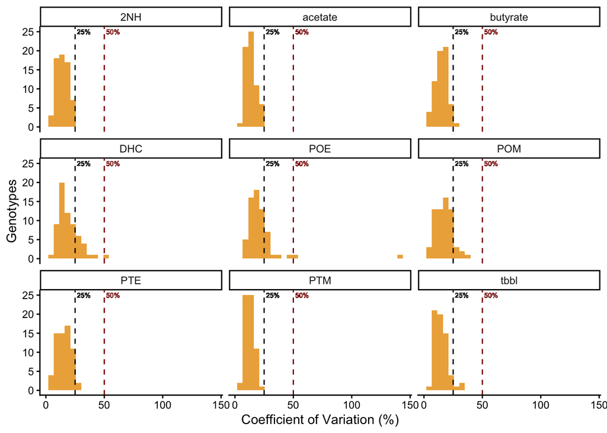

```r
cv_fig <- processed_mean_data %>%
  ggplot(aes(x = cv)) +
  geom_histogram(fill = golden) +
  facet_wrap(~ substrate) +
  geom_vline(xintercept = 25, lty = 2) +
  geom_text(aes(x = 32.5, y = 25, label = "25%"), size = 2) +
  geom_vline(xintercept = 50, lty = 2, col = "darkred") +
  geom_text(aes(x = 57.5, y = 25, label = "50%"), size = 2, col = "darkred") +
  labs(x = "Coefficient of Variation (%)", y = "Genotypes") +
  theme_classic()

cv_fig
```

```r
##ggsave("cv_fig.svg", plot = cv_fig, width = 180, height = 247/3, dpi = 300, units = "mm")
```

As well as the mean absolute error:

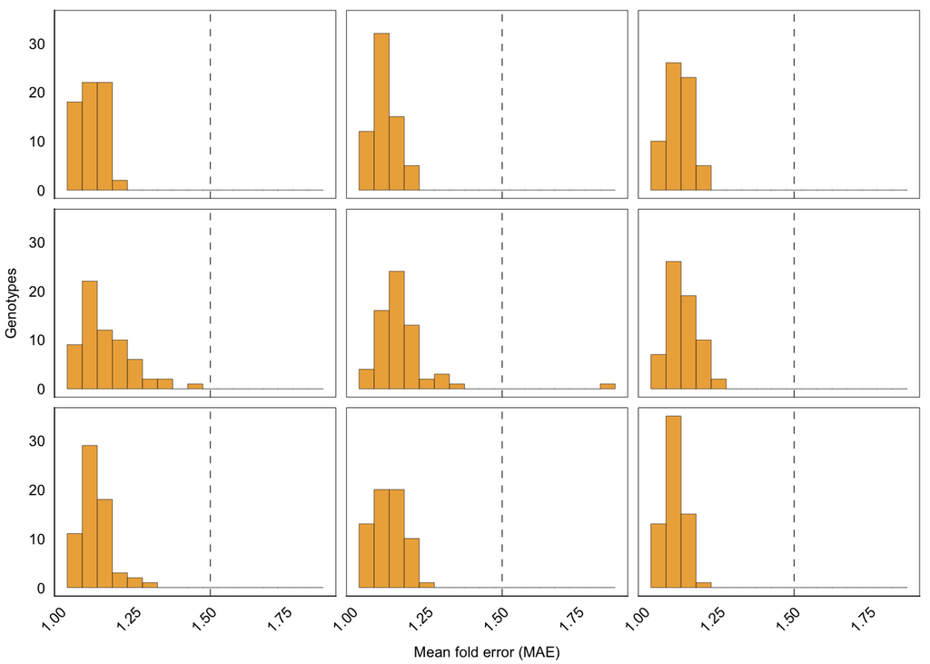

```r
new_order <- c("2NH", "acetate", "butyrate",
               "DHC", "POE", "POM",
               "tbbl", "PTE", "PTM")

mae_fig <- processed_mean_data %>%
  mutate(substrate = factor(substrate, levels = new_order)) %>%
  ggplot(aes(x = mean_fold_error)) +
  geom_histogram(fill = golden, color = "black", linewidth = 0.1, binwidth = 0.05) +
  facet_wrap(~ substrate) +
  geom_vline(xintercept = 1.5, lty = 2, linewidth = 0.2) +
  #geom_text(aes(x = 1.58, y = 22.5, label = "1.5-fold"), size = 2) +
  #geom_vline(xintercept = 2, lty = 2, col = "darkred") +
  #geom_text(aes(x = 1.93, y = 22.5, label = "2-fold"), size = 2, col = "darkred") +
  labs(x = "Mean fold error (MAE)", y = "Genotypes") +
  #ylim(0, 25) +
  theme_classic() +
  theme(
    strip.background = element_blank(),
    strip.text.x = element_blank(),
    panel.background = element_blank(),
    panel.border = element_rect(fill = NA, color = "black", linewidth = 0.3),
    axis.line = element_line(colour = "black", linewidth=0.25),
    axis.ticks = element_line(linewidth = 0),
    axis.title = element_text(size = 8),
    axis.title.x = element_text(vjust = -1),
    axis.title.y = element_text(vjust = 2.5),
    axis.text = element_text(size = 8),
    axis.text.x = element_text(angle = 45, hjust = 1)
  )

mae_fig
```

```r
ggsave("mae_fig_v2.svg", plot = mae_fig, width = 180/2.5, height = 180/3.5, dpi = 600, units = "mm")
```

## 1.3 Creating a normalized dataframe

### 1.3.1 Ensuring log-transformed data is normally distributed

As the title says. To do this, it is worth collecting all the data, subtracting by the mean (to set the mean equal to 0) for each reference/substrate pair, then pooling all the data to verify that it is normally distributed (i.e. the errors on the log scale are normally distributed)

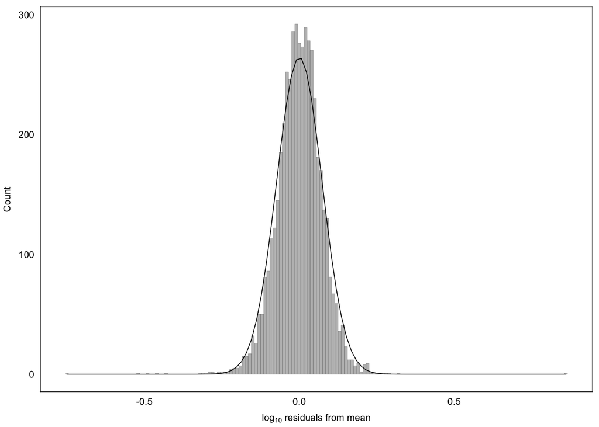

```r
norm_data <- processed_data %>%
  group_by(substrate) %>%
  mutate(norm_activity = activity/mean(activity[reference == "DHLFFI"]), # Normalize by the mean activity of the wt sequence for each sub
         norm_activity = log10(norm_activity)) %>% # Log-transform
  ungroup() %>%
  group_by(substrate, reference) %>%
  mutate(norm_value = norm_activity - mean(norm_activity)) %>% # Set mean of each measurement to 0
  ungroup()

n_obs <- nrow(norm_data)
bw <- 0.01

norm_fig <- norm_data %>%
  ggplot(aes(x = norm_value)) +
  geom_histogram(binwidth = bw, fill = "grey", color = "black", lwd = 0.05) + # Default is count
  stat_function(fun = function(x) dnorm(x, mean = mean(norm_data$norm_value),
                                           sd = sd(norm_data$norm_value)) * n_obs * bw,
                colour = "black",
                linewidth = 0.3) +
  labs(x = expression("log"[10]*" residuals from mean"),
       y = "Count") +
  theme_classic() +
  theme(
    panel.background = element_blank(),
    panel.border = element_rect(fill = NA, color = "black", linewidth = 0.3),
    axis.line = element_line(colour = "black", linewidth=0.25),
    axis.ticks = element_line(linewidth = 0),
    axis.title = element_text(size = 8),
    axis.title.x = element_text(vjust = -1),
    axis.title.y = element_text(vjust = 2.5),
    axis.text = element_text(size = 8),
  )

norm_fig
```

```r
ggsave("norm_fig_v2.svg", plot = norm_fig, width = 180/2.5, height = 180/3.5, dpi = 600, units = "mm")
```

And the qqplot

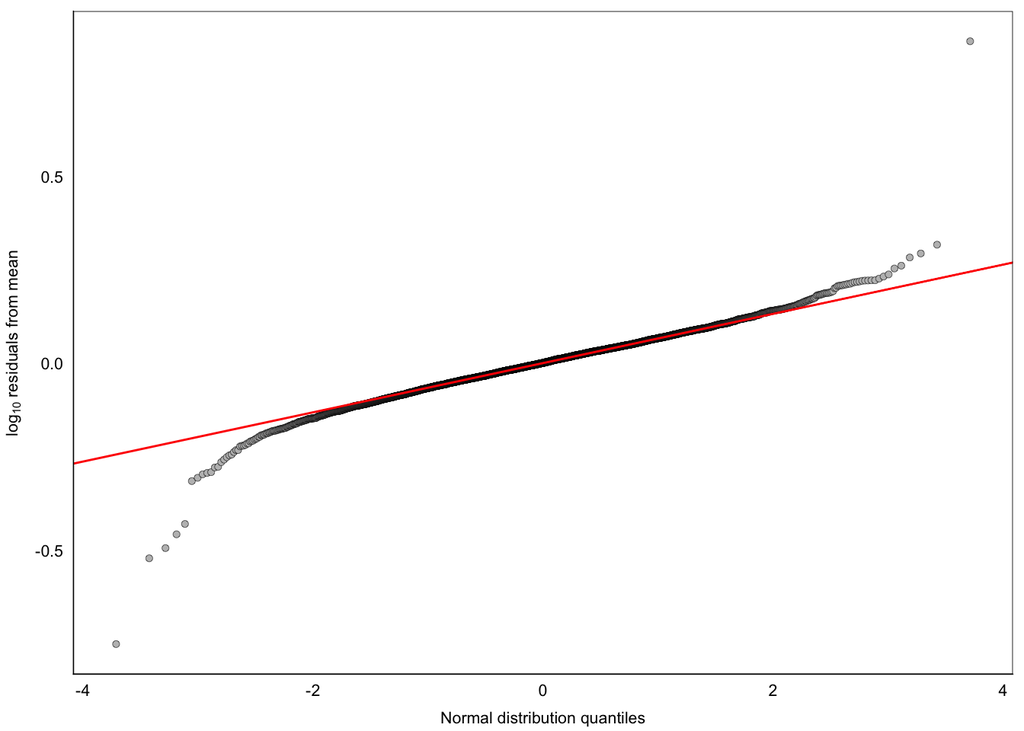

```r
#qqnorm(norm_data$norm_value, pch = 1, frame = FALSE)
#qqline(norm_data$norm_value, col = "steelblue", lwd = 2)

library(patchwork)

# Create the QQ plot
qq_inset <- norm_data %>%
  ggplot(aes(sample = norm_value)) +
  stat_qq(size = 1.5, shape = 21, fill = "grey", color = "black", stroke = 0.15) +
  stat_qq_line(color = "red") +
  labs(x = "Normal distribution quantiles",
       y = expression("log"[10]*" residuals from mean"),
       title = NULL) +
  theme_classic() +
  theme(
    panel.background = element_blank(),
    panel.border = element_rect(fill = NA, color = "black", linewidth = 0.3),
    axis.line = element_line(colour = "black", linewidth=0.25),
    axis.ticks = element_line(linewidth = 0),
    axis.title = element_text(size = 8),
    axis.title.x = element_text(vjust = -1),
    axis.title.y = element_text(vjust = 2.5),
    axis.text = element_text(size = 8),
  )

qq_inset
```

```r
ggsave("qqplot_fig_v2.svg", plot = qq_inset, width = 180/2.5, height = 180/3.5, dpi = 600, units = "mm")
```

### 1.3.2 Alternative normaliziation

I’m also curious if I can log-transform first, followed by normalization by subtraction:

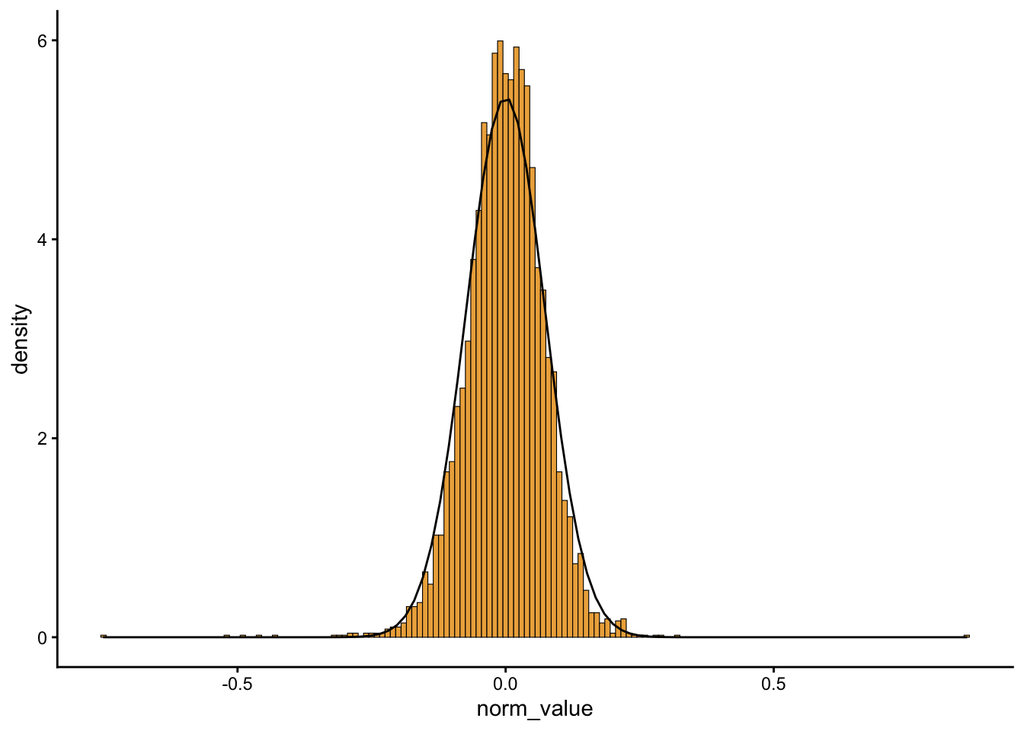

```r
norm_data_2 <- processed_data %>%
  group_by(substrate) %>%
  mutate(norm_activity = log10(activity), # Log-transform,
         norm_activity = norm_activity - mean(norm_activity[reference == "DHLFFI"])) %>% # Normalize by the mean activity of the wt sequence for each sub
  ungroup() %>%
  group_by(substrate, reference) %>%
  mutate(norm_value = norm_activity - mean(norm_activity)) # Set mean of each measurement to 0

norm_data_2 %>%
  ggplot(aes(x = norm_value)) +
  geom_histogram(aes(y = after_stat(density)), binwidth = 0.01, color = "black", fill = golden, lwd = 0.2) +
  stat_function(fun = dnorm, args = list(mean = mean(norm_data_2$norm_value), sd = sd(norm_data_2$norm_value)), colour = "black") +
  theme_classic()
```

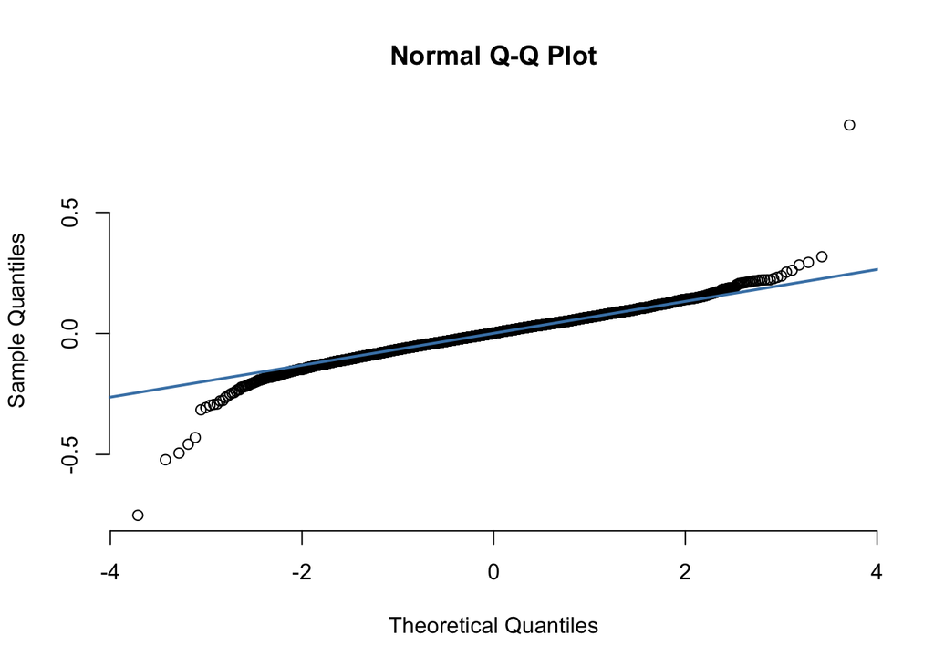

```r
qqnorm(norm_data_2$norm_value, pch = 1, frame = FALSE)
qqline(norm_data_2$norm_value, col = "steelblue", lwd = 2)
```

These look identical. It is just a matter of which mean is the reference mean I suppose? Thus, I am dealing on the log-scale and if I back-transform I need to use the log-based mean and SDs, not the individual values.

### 1.3.3 Creating a data frame with statistics

It may be useful to have a data frame that describes all of the general statistics. Since we’ve tested for normality, it is fair to get a mean and SD directly from the log-transformed data. **Note:** when you use these values to convert back to a fold-change scale, you will obtain a geometric mean of the fold-change. This is probably fair as “fold-change errors” are likely log-normal, this GM and GMSD are better metrics for those.

```r
normalized_bulky_mean_data <- norm_data %>%
  select(-c("replicate", "activity", "exp_day", "plate_id", "norm_value")) %>%
  group_by(p233, p254, p271, p272, p306, p313, substrate, reference) %>%
  # Error propagation - http://surl.li/qrptg
  summarize(mean_value = mean(norm_activity),
         sd_value = sd(norm_activity),
         total_entries = n()) %>%
  mutate(se_value = sd_value / sqrt(total_entries) ) %>%
  ungroup()

knitr::kable(
  head(normalized_bulky_mean_data)
)
```

| p233 | p254 | p271 | p272 | p306 | p313 | substrate | reference | mean_value | sd_value | total_entries | se_value |
| --- | --- | --- | --- | --- | --- | --- | --- | --- | --- | --- | --- |
| 0 | 0 | 0 | 0 | 0 | 0 | 2NH | DHLFFI | -0.0046060 | 0.0643757 | 30 | 0.0117533 |
| 0 | 0 | 0 | 0 | 0 | 0 | DHC | DHLFFI | -0.0031372 | 0.0546747 | 25 | 0.0109349 |
| 0 | 0 | 0 | 0 | 0 | 0 | POE | DHLFFI | -0.0097104 | 0.0936002 | 29 | 0.0173811 |
| 0 | 0 | 0 | 0 | 0 | 0 | POM | DHLFFI | -0.0103967 | 0.0965726 | 30 | 0.0176317 |
| 0 | 0 | 0 | 0 | 0 | 0 | PTE | DHLFFI | -0.0029510 | 0.0514661 | 30 | 0.0093964 |
| 0 | 0 | 0 | 0 | 0 | 0 | PTM | DHLFFI | -0.0093296 | 0.0930209 | 30 | 0.0169832 |

## 1.4 Monitor across day variation

To do later… Probably some ANOVA across PTE-S6 as this is a nice “constant” with plenty of replicates across plates and days

## 1.5 Monitor across plate variation

To do later… see above

# 2 Looking at SMEs

Already did this elsewhere but just for plotting sake:

```r
subs <- c("2NH", "acetate", "butyrate",
               "DHC", "POE", "POM",
               "tbbl", "PTE", "PTM")

# Function to calculate single mutational effects
calculate_single_mutational_effects <- function(data, positions = NULL) {

  # Tibble for storing results for each substrate
  results <- tibble()

  for(sub in 1:length(subs)){

    # If positions not specified, use all position columns (assuming they start with 'p')
    if (is.null(positions)) {
      positions <- names(data)[grepl("^p", names(data))]
    }

    # Calculate stats for all genotypes
    genotype_stats <- data %>%
      filter(substrate == subs[sub]) %>%
      select(c(all_of(positions), substrate, mean_activity, sd_activity, total_entries)) %>%
      # Create a genotype identifier
      unite("genotype", all_of(positions), sep = "", remove = FALSE)

    # Find the all-wild-type background (all positions = 0)
    all_wt_genotype <- paste0(rep("0", length(positions)), collapse = "")
    wt_reference <- genotype_stats %>%
      filter(genotype == all_wt_genotype)

    if (nrow(wt_reference) != 1 || is.na(wt_reference$mean_activity)) {
      stop("Could not find valid all-wild-type reference genotype")
    }

    for (i in seq_along(positions)) {
      pos_name <- positions[i]
      other_positions <- positions[-i]

      # Get all unique backgrounds for the other positions
      if (length(other_positions) > 0) {
        backgrounds <- genotype_stats %>%
          select(all_of(other_positions)) %>%
          distinct()

        for (j in 1:nrow(backgrounds)) {
          background_row <- backgrounds[j, ]

          # Find matching genotypes
          wt_condition <- genotype_stats
          mut_condition <- genotype_stats

          # Filter by background
          for (pos in other_positions) {
            wt_condition <- wt_condition %>% filter(!!sym(pos) == background_row[[pos]])
            mut_condition <- mut_condition %>% filter(!!sym(pos) == background_row[[pos]])
          }

          # Filter by target position
          wt_condition <- wt_condition %>% filter(!!sym(pos_name) == 0)
          mut_condition <- mut_condition %>% filter(!!sym(pos_name) == 1)

          if (nrow(wt_condition) == 1 && nrow(mut_condition) == 1 &&
              !is.na(wt_condition$mean_activity) && !is.na(mut_condition$mean_activity) &&
              wt_condition$mean_activity > 0 && mut_condition$mean_activity > 0) {

            # Calculate fold change relative to all-WT background
            wt_fold_change <- wt_condition$mean_activity / wt_reference$mean_activity
            mut_fold_change <- mut_condition$mean_activity / wt_reference$mean_activity

            # Calculate the ratio (mutant fold change / WT fold change)
            effect_ratio <- mut_fold_change / wt_fold_change

            # Error propagation for ratios
            # For wt_fold_change = wt_condition / wt_reference
            cv_wt_fold <- sqrt(wt_condition$sd_activity^2 + wt_reference$sd_activity^2)
            sd_wt_fold <- wt_fold_change * cv_wt_fold

            # For mut_fold_change = mut_condition / wt_reference
            cv_mut_fold <- sqrt(mut_condition$sd_activity^2 + wt_reference$sd_activity^2)
            sd_mut_fold <- mut_fold_change * cv_mut_fold

            # For effect_ratio = mut_fold_change / wt_fold_change
            cv_effect_ratio <- sqrt(cv_mut_fold^2 + cv_wt_fold^2)
            effect_sd <- effect_ratio * cv_effect_ratio

            # Calculate SEM for the ratio (approximate - assumes independent measurements)
            # This is an approximation since we're combining different sample sizes
            effective_n <- min(wt_condition$total_entries, mut_condition$total_entries, wt_reference$total_entries)
            effect_sem <- effect_sd / sqrt(effective_n)

            # Log-transformed values (log10 instead of log2)
            log_effect <- log10(effect_ratio)
            # For log transformation: SD_log = SD_ratio / (ratio * ln(10)) for log10
            log_effect_sd <- effect_sd / (effect_ratio * log(10))
            log_effect_sem <- effect_sem / (effect_ratio * log(10))

            # Create background string
            background_string <- paste0(background_row, collapse = "")

            # Create variant ID with X at the position being mutated
            variant_genotype <- strsplit(wt_condition$genotype, "")[[1]]
            variant_genotype[i] <- "X"
            variant_id <- paste0(variant_genotype, collapse = "")

            results <- bind_rows(results, tibble(
              position = pos_name,
              variant_id = variant_id,
              background = subs[sub],
              effect_ratio = effect_ratio,
              effect_sd = effect_sd,
              effect_sem = effect_sem,
              log10_effect = log_effect,
              log10_effect_sd = log_effect_sd,
              log10_effect_sem = log_effect_sem,
              wt_genotype = wt_condition$genotype,
              mut_genotype = mut_condition$genotype,
              wt_mean = wt_condition$mean_activity,
              mut_mean = mut_condition$mean_activity,
              wt_fold_vs_reference = wt_fold_change,
              mut_fold_vs_reference = mut_fold_change,
              wt_n = wt_condition$total_entries,
              mut_n = mut_condition$total_entries
            ))
          }
        }
      }
    }
    }

  return(results)
}
```

And we run

```r
smes_pte <- calculate_single_mutational_effects(processed_mean_data)
```

Then do some plotting

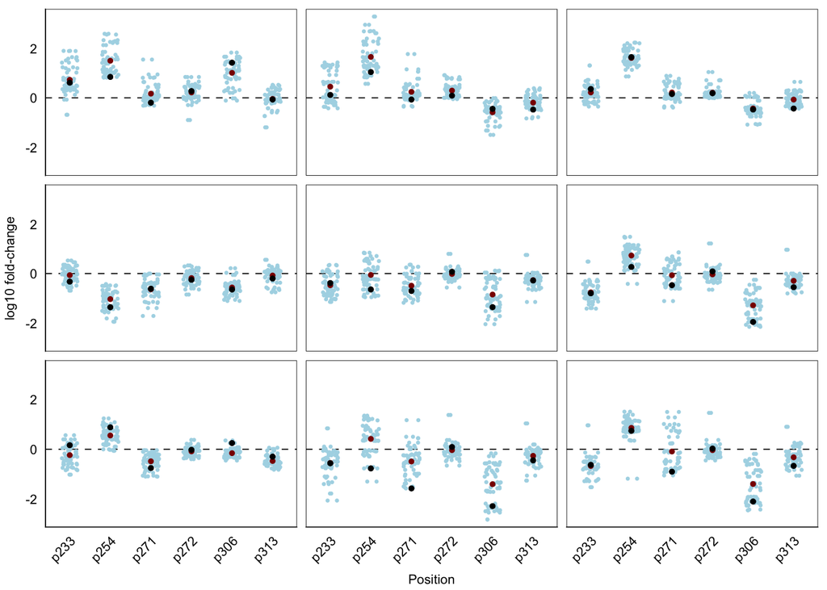

```r
positions <- c('p233', 'p254', 'p271', 'p272', 'p306', 'p313')

position_summary <- smes_pte %>%
  mutate(position = factor(position, levels = positions),
         background = factor(background, levels = new_order)) %>%
  group_by(position, background) %>%
  summarise(log10_effect = mean(log10_effect))

position_summary_2 <- smes_pte %>%
  mutate(position = factor(position, levels = positions),
         background = factor(background, levels = new_order)) %>%
  group_by(position, background) %>%
  mutate(additional_mut = str_count(variant_id, '1')) %>%
  filter(additional_mut == 0)

smes_pte %>%
  mutate(position = factor(position, levels = positions),
         background = factor(background, levels = new_order)) %>%
  ggplot(aes(x = position, y = log10_effect)) +
  facet_wrap(~background) +
  geom_hline(yintercept = 0, lty = 2, linewidth = 0.3) +
  geom_jitter(width = 0.2, color = "lightblue", size = 0.5) +
  #geom_point(color = "lightblue", size = 0.5) +
  geom_point(data = position_summary, aes(y = log10_effect),
             color = "darkred", size = 1) +
  geom_point(data = position_summary_2, aes(y = log10_effect),
             color = "black", size = 1) +
  labs(x = "Position",
       y = "log10 fold-change") +
  #ylim(c(-4, 4)) +
  theme_classic() +
  theme(
    strip.background = element_blank(),
    strip.text.x = element_blank(),
    panel.background = element_blank(),
    panel.border = element_rect(fill = NA, color = "black", linewidth = 0.3),
    axis.line = element_line(colour = "black", linewidth=0.25),
    axis.ticks = element_line(linewidth = 0),
    axis.title = element_text(size = 8),
    axis.title.x = element_text(vjust = -1),
    axis.title.y = element_text(vjust = 2.5),
    axis.text = element_text(size = 8),
    axis.text.x = element_text(angle = 45, hjust = 1)
  )
```

Or we wrap by position

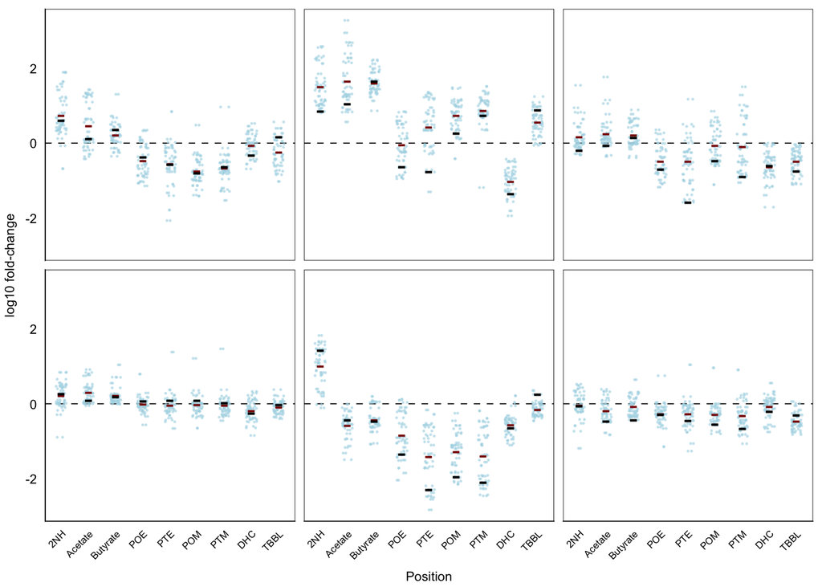

```r
other_subs_order <- c("2NH", "Acetate", "Butyrate", "POE", "PTE", "POM", "PTM", "DHC", "TBBL")

position_summary <- smes_pte %>%
  mutate(position = factor(position, levels = positions),
         background = case_when(background == "acetate" ~ "Acetate",
                                background == "butyrate" ~ "Butyrate",
                                background == "tbbl" ~ "TBBL",
                                TRUE ~ background),
         background = factor(background, levels = other_subs_order)) %>%
  group_by(position, background) %>%
  summarise(log10_effect = mean(log10_effect))

position_summary_2 <- smes_pte %>%
  mutate(position = factor(position, levels = positions),
         background = case_when(background == "acetate" ~ "Acetate",
                                background == "butyrate" ~ "Butyrate",
                                background == "tbbl" ~ "TBBL",
                                TRUE ~ background),
         background = factor(background, levels = other_subs_order)) %>%
  group_by(position, background) %>%
  mutate(additional_mut = str_count(variant_id, '1')) %>%
  filter(additional_mut == 0)

smes_fig <- smes_pte %>%
  mutate(position = factor(position, levels = positions),
         background = case_when(background == "acetate" ~ "Acetate",
                                background == "butyrate" ~ "Butyrate",
                                background == "tbbl" ~ "TBBL",
                                TRUE ~ background),
         background = factor(background, levels = other_subs_order)) %>%
  ggplot(aes(x = background, y = log10_effect)) +
  facet_wrap(~ position) +
  geom_hline(yintercept = 0, lty = 2, linewidth = 0.3) +
  geom_jitter(width = 0.2, color = "lightblue", size = 0.2, alpha = 0.5) +
  #geom_point(color = "lightblue", size = 0.5) +
  geom_point(data = position_summary, aes(y = log10_effect),
             color = "darkred", size = 5, shape = "-") +
  geom_point(data = position_summary_2, aes(y = log10_effect),
             color = "black", size = 5, shape = "-") +
  labs(x = "Position",
       y = "log10 fold-change") +
  #ylim(c(-4, 4)) +
  theme_classic() +
  theme(
    strip.background = element_blank(),
    strip.text.x = element_blank(),
    panel.background = element_blank(),
    panel.border = element_rect(fill = NA, color = "black", linewidth = 0.3),
    axis.line = element_line(colour = "black", linewidth=0.25),
    axis.ticks = element_line(linewidth = 0),
    axis.title = element_text(size = 8),
    axis.title.x = element_text(vjust = -1),
    axis.title.y = element_text(vjust = 2.5),
    axis.text.y = element_text(size = 8),
    axis.text.x = element_text(angle = 45, hjust = 1, size = 6)
  )

smes_fig
```

```r
ggsave("fig_4_a.svg", plot = smes_fig, width = 180/1.75, height = 180/2.7, dpi = 600, units = "mm")
```

# 3 Epistasis tests

## 3.1 Generating SMEs and EEs

```r
## Helper functions

error_prop <- function(x){
  return(sqrt(sum(x**2)))
}

harm_mean <- function(x){
  return(length(x)/sum(1/x))
}

alternate_sub_add <- function(x){
  # Takes the last term and alternates between subtracting and adding the next term to the left
  y = x[length(x)]
  counter = T
  if(length(x) > 1) {
    for(i in (length(x)-1):1){
      if(counter){
        y = y - x[i]
        counter = F
      } else{
        y = y + x[i]
        counter = T
      }
    }
  }
  return(y)
}

## There is probably a better way to do this but here it is:

# Generate all possible combinations of numbers 1 to 6
all_combinations <- lapply(1:6, function(x) combn(1:6, x, simplify = FALSE))

# Combine all combinations into a single list
combined_combinations <- unlist(all_combinations, recursive = FALSE)

###

ees = data.frame()

for(sub in 1:length(unique(normalized_bulky_mean_data$substrate))){

  temp_small_data <- normalized_bulky_mean_data %>%
    filter(substrate == unique(normalized_bulky_mean_data$substrate)[sub])

  for(combo in 1:length(combined_combinations)) {
    if(combo != length(combined_combinations)) {
      temp_small_data_ready <- temp_small_data %>%
      rowwise() %>%
      mutate(muts = sum(p233, p254, p271, p272, p306, p313)) %>%
      ungroup() %>%
      filter_at(vars(combined_combinations[[combo]]), all_vars(. != 1)) %>%
      group_by(muts)
    } else {
      temp_small_data_ready <- temp_small_data %>%
      rowwise() %>%
      mutate(muts = sum(p233, p254, p271, p272, p306, p313)) %>%
      ungroup() %>%
      group_by(muts)
    }

    cur_harm_mean <- temp_small_data_ready %>% pull(total_entries) %>% harm_mean() # Get harmonic mean

    # Calculate epistasis with error propagation
    next_term <- temp_small_data_ready %>%
      summarize(new_val = sum(mean_value),
                new_se = error_prop(se_value)) %>%
      ungroup() %>%
      summarize(new_val = alternate_sub_add(new_val),
                new_se = error_prop(new_se)) %>%
      mutate(new_n = cur_harm_mean)

    ref_geno = "000000"
    current = unique(which(!(seq(1, 6, 1) %in% combined_combinations[[combo]])))
    if(length(current) > 0){
      for(number in 1:length(current)){
        substr(ref_geno, current[number], current[number]) <- 'x'
      }
    } else {
      ref_geno = "xxxxxx"
    }

    ees = rbind(ees, next_term %>% mutate(geno = ref_geno,
                                          sub = unique(normalized_bulky_mean_data$substrate)[sub]))
  }
}

ees <- ees %>% distinct() # Remove duplicates
```

## 3.2 Significance testing of EEs

Next comes significance testing. Thanks to Dan for the code to perform the adjusted p-value. **Note: something seems off with the harmonic mean for the 6th order terms. I need to check on that.**

```r
## SOMETHING IS WRONG WITH THE HARMONIC MEAN FOR THE 6TH ORDER TERM

test_ees <- ees %>%
  mutate(t = (new_val)/new_se,
         p= 2*pt(abs(t),df=new_n-1,lower=F)) %>%
  mutate(padj = p.adjust(p,method = 'fdr'),n=nrow(.),
         muts = str_count(geno, 'x'),
         sig = padj < 0.05)

knitr::kable(
  head(test_ees)
)
```

| new_val | new_se | new_n | geno | sub | t | p | padj | n | muts | sig |
| --- | --- | --- | --- | --- | --- | --- | --- | --- | --- | --- |
| -0.3785409 | 0.1316120 | 8.158640 | 0xxxxx | 2NH | -2.876189 | 0.0232117 | 0.0378381 | 567 | 5 | TRUE |
| 0.6988283 | 0.1338426 | 8.158640 | x0xxxx | 2NH | 5.221268 | 0.0011407 | 0.0028620 | 567 | 5 | TRUE |
| 0.4919336 | 0.1278367 | 7.933884 | xx0xxx | 2NH | 3.848141 | 0.0064233 | 0.0125680 | 567 | 5 | TRUE |
| -1.7499222 | 0.1384085 | 7.933884 | xxx0xx | 2NH | -12.643172 | 0.0000048 | 0.0000280 | 567 | 5 | TRUE |
| -0.7113436 | 0.1549673 | 7.826087 | xxxx0x | 2NH | -4.590282 | 0.0026813 | 0.0060091 | 567 | 5 | TRUE |
| -0.8110307 | 0.1116861 | 8.275862 | xxxxx0 | 2NH | -7.261695 | 0.0001394 | 0.0004880 | 567 | 5 | TRUE |

Finally we can visualize this in volcano plots to look at EEs (x-axis) vs significance (y-axis):

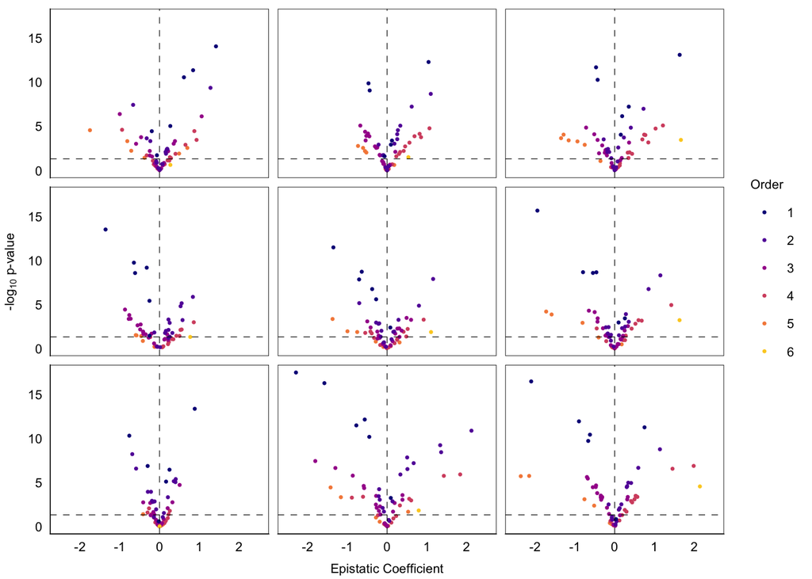

```r
new_order <- c("2NH", "acetate", "butyrate",
               "DHC", "POE", "POM",
               "tbbl", "PTE", "PTM")

volcano_fig <- test_ees %>%
  #filter(muts > 1) %>%
  mutate(sub = factor(sub, levels = new_order),
         muts = factor(muts)) %>%
  ggplot(aes(x = new_val, y = -1*log10(padj), color = muts)) +
  geom_point(size = 0.5) +
  geom_hline(yintercept = -log10(0.05), lty = 2, linewidth = 0.2) +
  geom_vline(xintercept = 0, lty = 2, linewidth = 0.2) +
  xlim(-2.5, 2.5) +
  facet_wrap(~ sub) +
  scale_color_viridis_d(option = "plasma", end = 0.9) +
  #guides(color = guide_legend(override.aes = list(size = 4))) +
  labs(x = "Epistatic Coefficient",
       y = expression("-log"[10]*" p-value"),
       color = "Order") +
  theme_classic() +
  theme(
    strip.background = element_blank(),
    strip.text.x = element_blank(),
    panel.background = element_blank(),
    panel.border = element_rect(fill = NA, color = "black", linewidth = 0.3),
    axis.line = element_line(colour = "black", linewidth=0.25),
    axis.ticks = element_line(linewidth = 0),
    axis.title = element_text(size = 8),
    axis.title.x = element_text(vjust = -1),
    axis.title.y = element_text(vjust = 2.5),
    axis.text = element_text(size = 8),
    legend.title = element_text(size = 8),
    legend.text = element_text(size = 8)
  )

volcano_fig
```

```r
#ggsave("fig_4_b.svg", plot = volcano_fig, width = 180/2, height = 180/2.8, dpi = 600, units = "mm")
```

## 3.3 Bespoke plotting for manuscript

### 3.3.1 271-313 esters

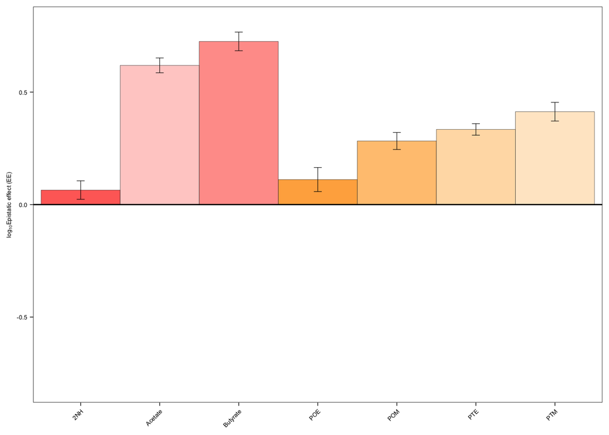

```r
bar_plot <- test_ees %>%
  filter(geno == "00x00x" & # 271-313
         (sub == "2NH" | sub == "acetate" | sub == "butyrate" |
            sub == "POE" | sub == "PTE" | sub == "POM" | sub == "PTM")) %>%
  mutate(sub = factor(sub, levels = new_order),
         sub = case_when(sub == "acetate" ~ "Acetate",
                         sub == "butyrate" ~ "Butyrate",
                         TRUE ~ sub)) %>%
  ggplot(aes(x = sub, y = new_val, fill = sub)) +
  # Set width to 1 to make them touch
  geom_col(color = "black", width = 1, linewidth = 0.1) +
  geom_errorbar(aes(ymin = new_val - new_se,
                    ymax = new_val + new_se),
                width = 0.1,
                linewidth = 0.2) +
  scale_fill_manual(values = c("#ff6e66", "#ffcfcc", "#ff9e99",  "#ffaf4d", "#ffc680", "#ffddb3", "#ffe8cc")) +
  geom_hline(yintercept = 0, linewidth = 0.5) +
  labs(y = expression("log"[10]*"Epistatic effect (EE)")) +
  ylim(-0.8, 0.8) +
  theme_classic() +
    theme(
    legend.position = "none",
    panel.border = element_rect(fill = NA, color = "black", linewidth = 0.3),
    axis.line = element_line(linewidth=0),
    axis.ticks = element_line(linewidth = 0.25),
    axis.title = element_text(size = 5),
    axis.title.x = element_blank(),
    axis.title.y = element_text(size = 5),
    axis.text.y = element_text(size = 5),
    axis.text.x = element_text(angle = 45, hjust = 1, size = 5)
  )

bar_plot
```

```r
ggsave("fig_6_2nh_271-313.svg", plot = bar_plot, width = 180/6, height = 180/6, dpi = 600, units = "mm")
```

```r
test_ees %>%
  filter((sub == "2NH" | sub == "acetate" | sub == "butyrate") &
           geno == "00x0x0") %>%
  mutate(new_val = 10^new_val)
```

```
## # A tibble: 3 × 11
##   new_val new_se new_n geno   sub            t     p  padj     n  muts sig
##     <dbl>  <dbl> <dbl> <chr>  <chr>      <dbl> <dbl> <dbl> <int> <int> <lgl>
## 1   1.02  0.0402  9.47 00x0x0 2NH       0.226  0.827 0.857   567     2 FALSE
## 2   1.01  0.0337  9.45 00x0x0 acetate   0.144  0.889 0.913   567     2 FALSE
## 3   0.998 0.0267  9.47 00x0x0 butyrate -0.0373 0.971 0.976   567     2 FALSE
```

### 3.3.2 233-254 esters

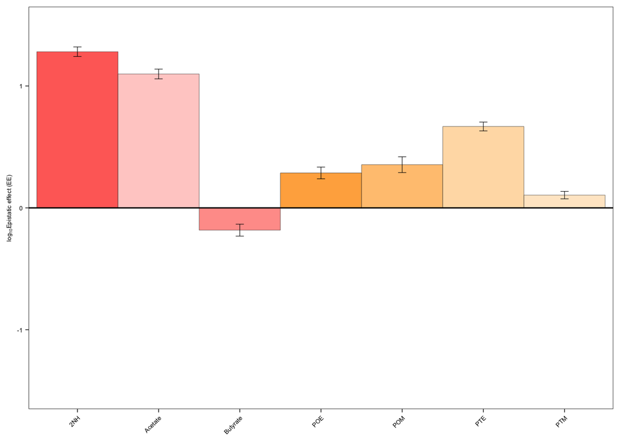

```r
bar_plot <- test_ees %>%
  filter(geno == "xx0000" & # 233-254
         (sub == "2NH" | sub == "acetate" | sub == "butyrate" |
            sub == "POE" | sub == "PTE" | sub == "POM" | sub == "PTM")) %>%
  mutate(sub = factor(sub, levels = new_order),
         sub = case_when(sub == "acetate" ~ "Acetate",
                         sub == "butyrate" ~ "Butyrate",
                         TRUE ~ sub)) %>%
  ggplot(aes(x = sub, y = new_val, fill = sub)) +
  # Set width to 1 to make them touch
  geom_col(color = "black", width = 1, linewidth = 0.1) +
  geom_errorbar(aes(ymin = new_val - new_se,
                    ymax = new_val + new_se),
                width = 0.1,
                linewidth = 0.2) +
  scale_fill_manual(values = c("#ff6e66", "#ffcfcc", "#ff9e99",  "#ffaf4d", "#ffc680", "#ffddb3", "#ffe8cc")) +
  geom_hline(yintercept = 0, linewidth = 0.5) +
  labs(y = expression("log"[10]*"Epistatic effect (EE)")) +
  ylim(-1.5, 1.5) +
  theme_classic() +
    theme(
    legend.position = "none",
    panel.border = element_rect(fill = NA, color = "black", linewidth = 0.3),
    axis.line = element_line(linewidth=0),
    axis.ticks = element_line(linewidth = 0.25),
    axis.title = element_text(size = 5),
    axis.title.x = element_blank(),
    axis.title.y = element_text(size = 5),
    axis.text.y = element_text(size = 5),
    axis.text.x = element_text(angle = 45, hjust = 1, size = 5)
  )

bar_plot
```

```r
ggsave("fig_6_2nh_233-254.svg", plot = bar_plot, width = 180/6, height = 180/6, dpi = 600, units = "mm")
```

### 3.3.3 306-313 esters

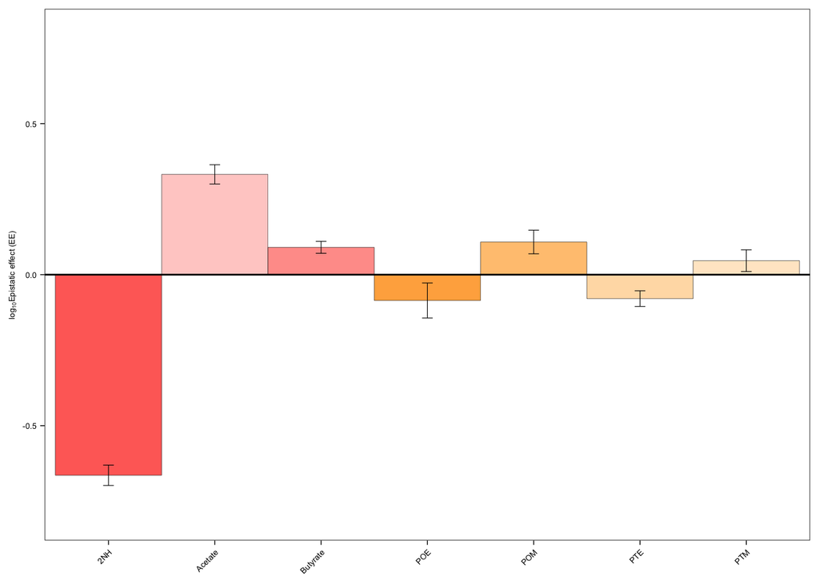

```r
bar_plot <- test_ees %>%
  filter(geno == "0000xx" & # 233-254
         (sub == "2NH" | sub == "acetate" | sub == "butyrate" |
            sub == "POE" | sub == "PTE" | sub == "POM" | sub == "PTM")) %>%
  mutate(sub = factor(sub, levels = new_order),
         sub = case_when(sub == "acetate" ~ "Acetate",
                         sub == "butyrate" ~ "Butyrate",
                         TRUE ~ sub)) %>%
  ggplot(aes(x = sub, y = new_val, fill = sub)) +
  # Set width to 1 to make them touch
  geom_col(color = "black", width = 1, linewidth = 0.1) +
  geom_errorbar(aes(ymin = new_val - new_se,
                    ymax = new_val + new_se),
                width = 0.1,
                linewidth = 0.2) +
  scale_fill_manual(values = c("#ff6e66", "#ffcfcc", "#ff9e99",  "#ffaf4d", "#ffc680", "#ffddb3", "#ffe8cc")) +
  geom_hline(yintercept = 0, linewidth = 0.5) +
  labs(y = expression("log"[10]*"Epistatic effect (EE)")) +
  ylim(-0.8, 0.8) +
  theme_classic() +
    theme(
    legend.position = "none",
    panel.border = element_rect(fill = NA, color = "black", linewidth = 0.3),
    axis.line = element_line(linewidth=0),
    axis.ticks = element_line(linewidth = 0.25),
    axis.title = element_text(size = 5),
    axis.title.x = element_blank(),
    axis.title.y = element_text(size = 5),
    axis.text.y = element_text(size = 5),
    axis.text.x = element_text(angle = 45, hjust = 1, size = 5)
  )

bar_plot
```

```r
ggsave("fig_6_2nh_306-313.svg", plot = bar_plot, width = 180/6, height = 180/6, dpi = 600, units = "mm")
```

### 3.3.4 271-306-313 esters

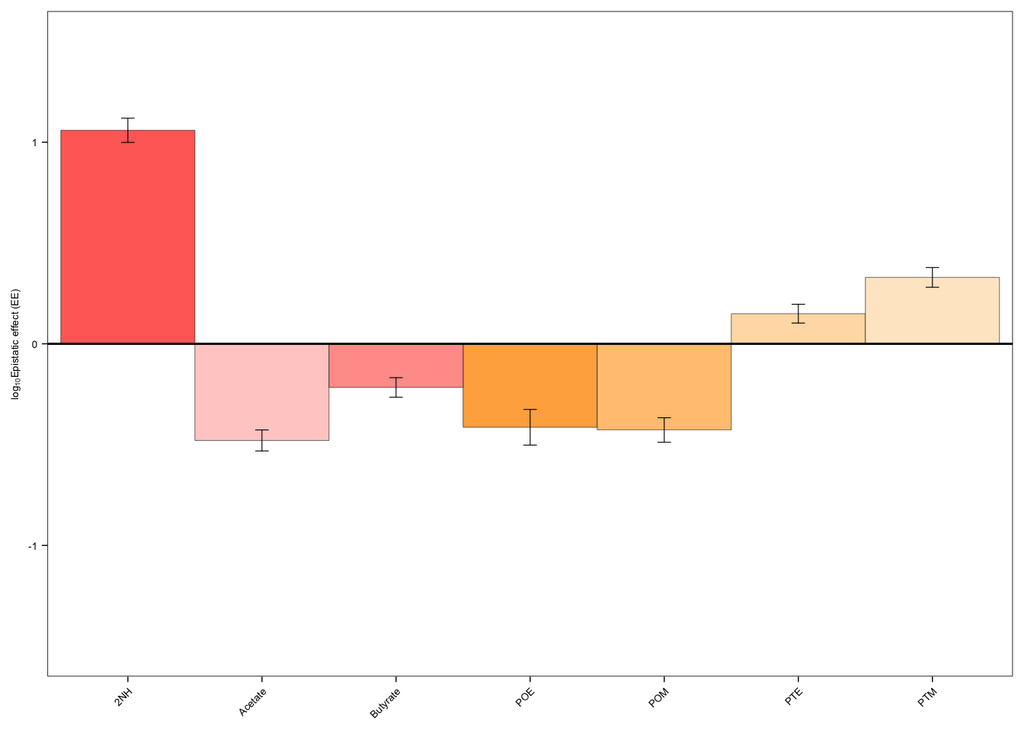

```r
bar_plot <- test_ees %>%
  filter(geno == "00x0xx" & # 233-254
         (sub == "2NH" | sub == "acetate" | sub == "butyrate" |
            sub == "POE" | sub == "PTE" | sub == "POM" | sub == "PTM")) %>%
  mutate(sub = factor(sub, levels = new_order),
         sub = case_when(sub == "acetate" ~ "Acetate",
                         sub == "butyrate" ~ "Butyrate",
                         TRUE ~ sub)) %>%
  ggplot(aes(x = sub, y = new_val, fill = sub)) +
  # Set width to 1 to make them touch
  geom_col(color = "black", width = 1, linewidth = 0.1) +
  geom_errorbar(aes(ymin = new_val - new_se,
                    ymax = new_val + new_se),
                width = 0.1,
                linewidth = 0.2) +
  scale_fill_manual(values = c("#ff6e66", "#ffcfcc", "#ff9e99",  "#ffaf4d", "#ffc680", "#ffddb3", "#ffe8cc")) +
  geom_hline(yintercept = 0, linewidth = 0.5) +
  labs(y = expression("log"[10]*"Epistatic effect (EE)")) +
  ylim(-1.5, 1.5) +
  theme_classic() +
    theme(
    legend.position = "none",
    panel.border = element_rect(fill = NA, color = "black", linewidth = 0.3),
    axis.line = element_line(linewidth=0),
    axis.ticks = element_line(linewidth = 0.25),
    axis.title = element_text(size = 5),
    axis.title.x = element_blank(),
    axis.title.y = element_text(size = 5),
    axis.text.y = element_text(size = 5),
    axis.text.x = element_text(angle = 45, hjust = 1, size = 5)
  )

bar_plot
```

```r
ggsave("fig_6_2nh_271-306-313.svg", plot = bar_plot, width = 180/6, height = 180/6, dpi = 600, units = "mm")
```

### 3.3.5 254-271 OPs

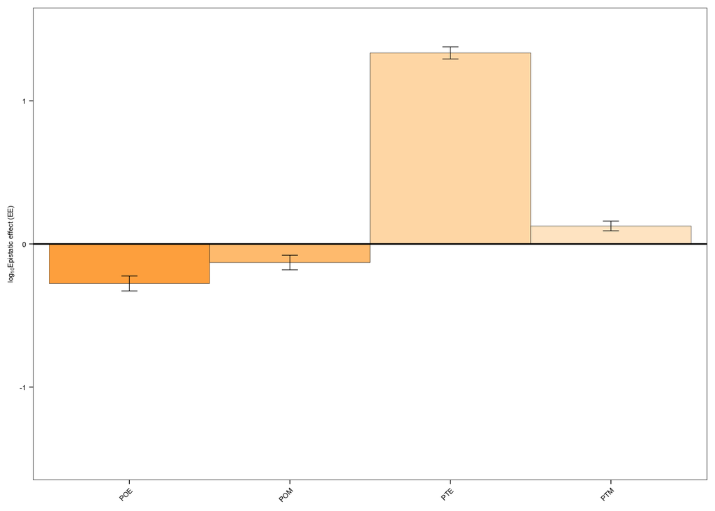

```r
bar_plot <- test_ees %>%
  filter(geno == "0xx000" &
         (sub == "POE" | sub == "PTE" | sub == "POM" | sub == "PTM")) %>%
  mutate(sub = factor(sub, levels = new_order),
         sub = case_when(sub == "acetate" ~ "Acetate",
                         sub == "butyrate" ~ "Butyrate",
                         TRUE ~ sub)) %>%
  ggplot(aes(x = sub, y = new_val, fill = sub)) +
  # Set width to 1 to make them touch
  geom_col(color = "black", width = 1, linewidth = 0.1) +
  geom_errorbar(aes(ymin = new_val - new_se,
                    ymax = new_val + new_se),
                width = 0.1,
                linewidth = 0.2) +
  scale_fill_manual(values = c("#ffaf4d", "#ffc680", "#ffddb3", "#ffe8cc")) +
  geom_hline(yintercept = 0, linewidth = 0.5) +
  labs(y = expression("log"[10]*"Epistatic effect (EE)")) +
  ylim(-1.5, 1.5) +
  theme_classic() +
    theme(
    legend.position = "none",
    panel.border = element_rect(fill = NA, color = "black", linewidth = 0.3),
    axis.line = element_line(linewidth=0),
    axis.ticks = element_line(linewidth = 0.25),
    axis.title = element_text(size = 5),
    axis.title.x = element_blank(),
    axis.title.y = element_text(size = 5),
    axis.text.y = element_text(size = 5),
    axis.text.x = element_text(angle = 45, hjust = 1, size = 5)
  )

bar_plot
```

```r
ggsave("fig_6_poe_254-271.svg", plot = bar_plot, width = 180/6, height = 180/6, dpi = 600, units = "mm")
```

### 3.3.6 233-254 OPs

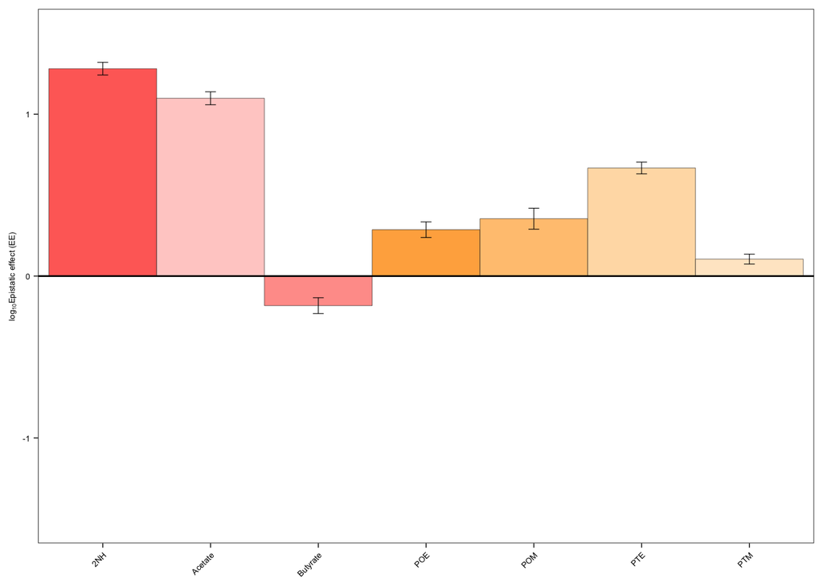

```r
bar_plot <- test_ees %>%
  filter(geno == "xx0000" &
         (sub == "2NH" | sub == "acetate" | sub == "butyrate" |
            sub == "POE" | sub == "PTE" | sub == "POM" | sub == "PTM")) %>%
  mutate(sub = factor(sub, levels = new_order),
         sub = case_when(sub == "acetate" ~ "Acetate",
                         sub == "butyrate" ~ "Butyrate",
                         TRUE ~ sub)) %>%
  ggplot(aes(x = sub, y = new_val, fill = sub)) +
  # Set width to 1 to make them touch
  geom_col(color = "black", width = 1, linewidth = 0.1) +
  geom_errorbar(aes(ymin = new_val - new_se,
                    ymax = new_val + new_se),
                width = 0.1,
                linewidth = 0.2) +
  scale_fill_manual(values = c("#ff6e66", "#ffcfcc", "#ff9e99",  "#ffaf4d", "#ffc680", "#ffddb3", "#ffe8cc")) +
  geom_hline(yintercept = 0, linewidth = 0.5) +
  labs(y = expression("log"[10]*"Epistatic effect (EE)")) +
  ylim(-1.5, 1.5) +
  theme_classic() +
    theme(
    legend.position = "none",
    panel.border = element_rect(fill = NA, color = "black", linewidth = 0.3),
    axis.line = element_line(linewidth=0),
    axis.ticks = element_line(linewidth = 0.25),
    axis.title = element_text(size = 5),
    axis.title.x = element_blank(),
    axis.title.y = element_text(size = 5),
    axis.text.y = element_text(size = 5),
    axis.text.x = element_text(angle = 45, hjust = 1, size = 5)
  )

bar_plot
```

```r
ggsave("fig_6_poe_233-254.svg", plot = bar_plot, width = 180/6, height = 180/6, dpi = 600, units = "mm")
```

### 3.3.7 233-313 OPs

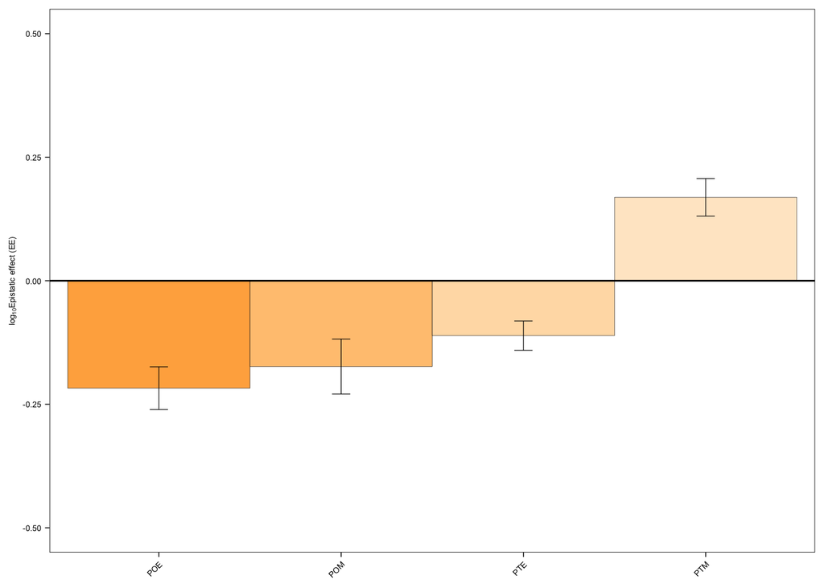

```r
bar_plot <- test_ees %>%
  filter(geno == "x0000x" &
         (sub == "POE" | sub == "PTE" | sub == "POM" | sub == "PTM")) %>%
  mutate(sub = factor(sub, levels = new_order),
         sub = case_when(sub == "acetate" ~ "Acetate",
                         sub == "butyrate" ~ "Butyrate",
                         TRUE ~ sub)) %>%
  ggplot(aes(x = sub, y = new_val, fill = sub)) +
  # Set width to 1 to make them touch
  geom_col(color = "black", width = 1, linewidth = 0.1) +
  geom_errorbar(aes(ymin = new_val - new_se,
                    ymax = new_val + new_se),
                width = 0.1,
                linewidth = 0.2) +
  scale_fill_manual(values = c("#ffaf4d", "#ffc680", "#ffddb3", "#ffe8cc")) +
  geom_hline(yintercept = 0, linewidth = 0.5) +
  labs(y = expression("log"[10]*"Epistatic effect (EE)")) +
  ylim(-0.5, 0.5) +
  theme_classic() +
    theme(
    legend.position = "none",
    panel.border = element_rect(fill = NA, color = "black", linewidth = 0.3),
    axis.line = element_line(linewidth=0),
    axis.ticks = element_line(linewidth = 0.25),
    axis.title = element_text(size = 5),
    axis.title.x = element_blank(),
    axis.title.y = element_text(size = 5),
    axis.text.y = element_text(size = 5),
    axis.text.x = element_text(angle = 45, hjust = 1, size = 5)
  )

bar_plot
```

```r
ggsave("fig_6_poe_233-313.svg", plot = bar_plot, width = 180/6, height = 180/6, dpi = 600, units = "mm")
```

### 3.3.8 254-306 OPs

PTE suffers from 254 and 306, the other OPs suffer only from 306 (aside POE). PTE seems to really bounce back in this background.

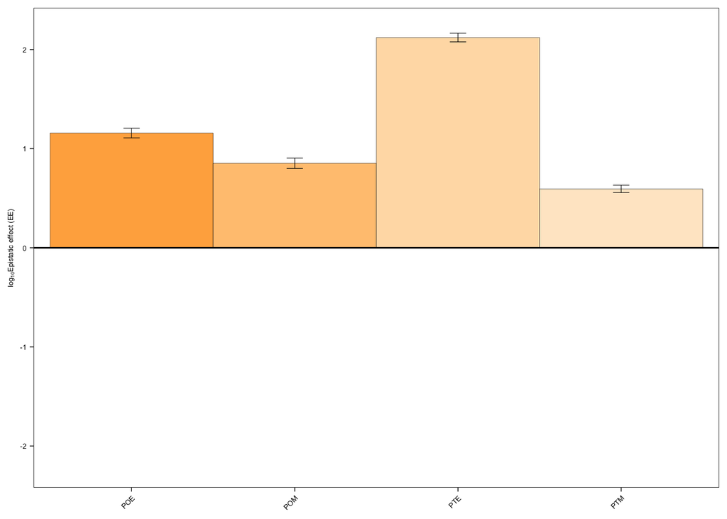

```r
bar_plot <- test_ees %>%
  filter(geno == "0x00x0" &
         (sub == "POE" | sub == "PTE" | sub == "POM" | sub == "PTM")) %>%
  mutate(sub = factor(sub, levels = new_order),
         sub = case_when(sub == "acetate" ~ "Acetate",
                         sub == "butyrate" ~ "Butyrate",
                         TRUE ~ sub)) %>%
  ggplot(aes(x = sub, y = new_val, fill = sub)) +
  # Set width to 1 to make them touch
  geom_col(color = "black", width = 1, linewidth = 0.1) +
  geom_errorbar(aes(ymin = new_val - new_se,
                    ymax = new_val + new_se),
                width = 0.1,
                linewidth = 0.2) +
  scale_fill_manual(values = c("#ffaf4d", "#ffc680", "#ffddb3", "#ffe8cc")) +
  geom_hline(yintercept = 0, linewidth = 0.5) +
  labs(y = expression("log"[10]*"Epistatic effect (EE)")) +
  ylim(-2.2, 2.2) +
  theme_classic() +
    theme(
    legend.position = "none",
    panel.border = element_rect(fill = NA, color = "black", linewidth = 0.3),
    axis.line = element_line(linewidth=0),
    axis.ticks = element_line(linewidth = 0.25),
    axis.title = element_text(size = 5),
    axis.title.x = element_blank(),
    axis.title.y = element_text(size = 5),
    axis.text.y = element_text(size = 5),
    axis.text.x = element_text(angle = 45, hjust = 1, size = 5)
  )

bar_plot
```

```r
ggsave("fig_6_poe_254-306.svg", plot = bar_plot, width = 180/6, height = 180/6, dpi = 600, units = "mm")
```

### 3.3.9 233-254-271 OPs

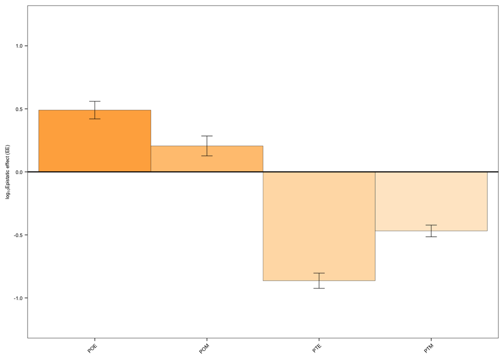

```r
bar_plot <- test_ees %>%
  filter(geno == "xxx000" &
         (sub == "POE" | sub == "PTE" | sub == "POM" | sub == "PTM")) %>%
  mutate(sub = factor(sub, levels = new_order),
         sub = case_when(sub == "acetate" ~ "Acetate",
                         sub == "butyrate" ~ "Butyrate",
                         TRUE ~ sub)) %>%
  ggplot(aes(x = sub, y = new_val, fill = sub)) +
  # Set width to 1 to make them touch
  geom_col(color = "black", width = 1, linewidth = 0.1) +
  geom_errorbar(aes(ymin = new_val - new_se,
                    ymax = new_val + new_se),
                width = 0.1,
                linewidth = 0.2) +
  scale_fill_manual(values = c("#ffaf4d", "#ffc680", "#ffddb3", "#ffe8cc")) +
  geom_hline(yintercept = 0, linewidth = 0.5) +
  labs(y = expression("log"[10]*"Epistatic effect (EE)")) +
  ylim(-1.2, 1.2) +
  theme_classic() +
    theme(
    legend.position = "none",
    panel.border = element_rect(fill = NA, color = "black", linewidth = 0.3),
    axis.line = element_line(linewidth=0),
    axis.ticks = element_line(linewidth = 0.25),
    axis.title = element_text(size = 5),
    axis.title.x = element_blank(),
    axis.title.y = element_text(size = 5),
    axis.text.y = element_text(size = 5),
    axis.text.x = element_text(angle = 45, hjust = 1, size = 5)
  )

bar_plot
```

```r
ggsave("fig_6_poe_233-254-271.svg", plot = bar_plot, width = 180/6, height = 180/6, dpi = 600, units = "mm")
```

### 3.3.10 271-306-313 OPs

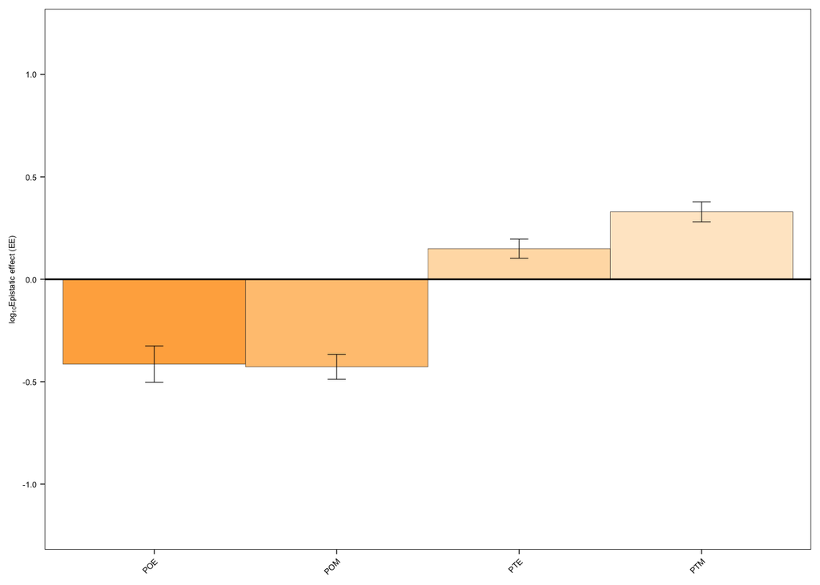

```r
bar_plot <- test_ees %>%
  filter(geno == "00x0xx" &
         (sub == "POE" | sub == "PTE" | sub == "POM" | sub == "PTM")) %>%
  mutate(sub = factor(sub, levels = new_order),
         sub = case_when(sub == "acetate" ~ "Acetate",
                         sub == "butyrate" ~ "Butyrate",
                         TRUE ~ sub)) %>%
  ggplot(aes(x = sub, y = new_val, fill = sub)) +
  # Set width to 1 to make them touch
  geom_col(color = "black", width = 1, linewidth = 0.1) +
  geom_errorbar(aes(ymin = new_val - new_se,
                    ymax = new_val + new_se),
                width = 0.1,
                linewidth = 0.2) +
  scale_fill_manual(values = c("#ffaf4d", "#ffc680", "#ffddb3", "#ffe8cc")) +
  geom_hline(yintercept = 0, linewidth = 0.5) +
  labs(y = expression("log"[10]*"Epistatic effect (EE)")) +
  ylim(-1.2, 1.2) +
  theme_classic() +
    theme(
    legend.position = "none",
    panel.border = element_rect(fill = NA, color = "black", linewidth = 0.3),
    axis.line = element_line(linewidth=0),
    axis.ticks = element_line(linewidth = 0.25),
    axis.title = element_text(size = 5),
    axis.title.x = element_blank(),
    axis.title.y = element_text(size = 5),
    axis.text.y = element_text(size = 5),
    axis.text.x = element_text(angle = 45, hjust = 1, size = 5)
  )

bar_plot
```

```r
ggsave("fig_6_poe_271-306-313.svg", plot = bar_plot, width = 180/6, height = 180/6, dpi = 600, units = "mm")
```

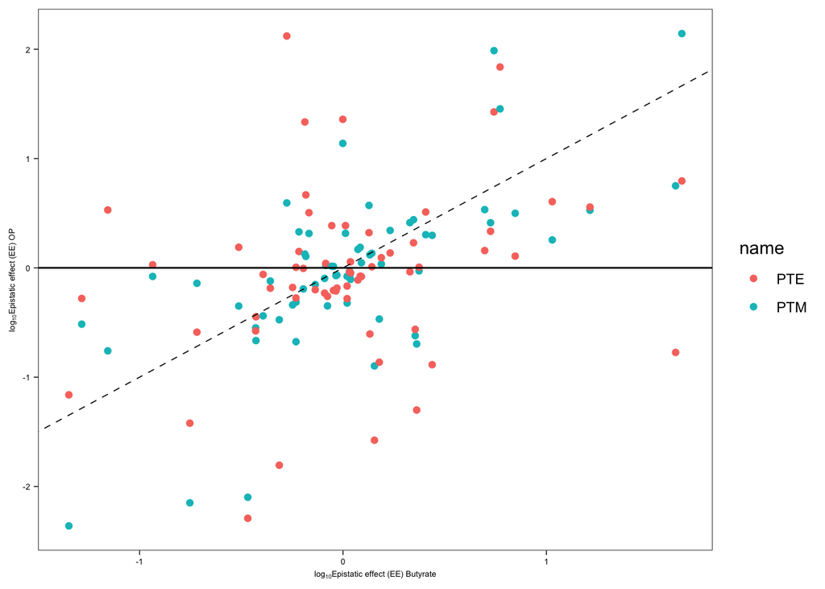

```r
test_ees %>%
  filter(sub %in% c("butyrate", "PTM", "PTE")) %>%
  mutate(sub_class = case_when(
    sub == "butyrate" ~ "ester",
    TRUE ~ "OP"
  )) %>%
  group_by(geno, sub) %>%
  summarise(new_val = mean(new_val, na.rm = TRUE), .groups = "drop") %>% # Change mean to sum/max as needed
  pivot_wider(names_from = sub, values_from = new_val) %>%
  pivot_longer(cols = c("PTM", "PTE")) %>%
  ggplot(aes(x = butyrate, y = value, color = name)) +
  geom_point() +
  geom_hline(yintercept = 0, linewidth = 0.5) +
  geom_abline(slope = 1, intercept = 0, linewidth = 0.3, lty = 2) +
  labs(x = expression("log"[10]*"Epistatic effect (EE) Butyrate"),
       y = expression("log"[10]*"Epistatic effect (EE) OP")) +
  theme_classic() +
    theme(
    #legend.position = "none",
    panel.border = element_rect(fill = NA, color = "black", linewidth = 0.3),
    axis.line = element_line(linewidth=0),
    axis.ticks = element_line(linewidth = 0.25),
    axis.title = element_text(size = 5),
    axis.title.x = element_text(size = 5),
    axis.title.y = element_text(size = 5),
    axis.text.y = element_text(size = 5),
    axis.text.x = element_text(size = 5)
  )
```

## 3.4 Epistatic coefficients across substrates

Quick heat map plotting

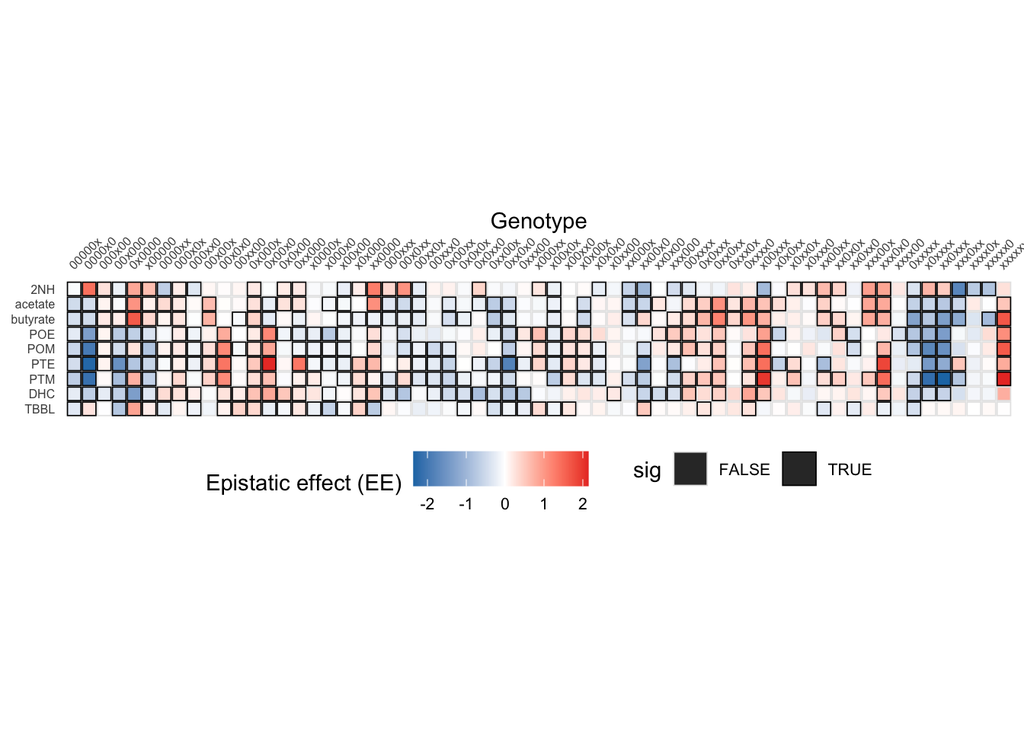

```r
heat_map_order <- c("2NH", "acetate", "butyrate", "POE", "POM", "PTE", "PTM", "DHC", "TBBL")

tile_2 <- test_ees %>%
  mutate(
    sig = ifelse(is.na(sig), FALSE, sig),
    geno = fct_reorder(geno, muts),
    sub = case_when(sub == "tbbl" ~ "TBBL", TRUE ~ sub),
    sub = factor(sub, levels = rev(heat_map_order))
  ) %>%
  ggplot(aes(x = geno, y = sub, fill = new_val)) +
  # Black border for significance, light grey for others to match the screenshot "grid" look
  geom_tile(aes(color = sig), width = 0.9, height = 0.9, linewidth = 0.3) +
  # Moving X axis to the top
  scale_x_discrete(position = "top") +
  scale_fill_gradient2(
    low = "#1F78B4", mid = "white", high = "#E31A1C",
    midpoint = mean(test_ees$new_val, na.rm = TRUE)
  ) +
  scale_color_manual(values = c("TRUE" = "black", "FALSE" = "grey90")) +
  theme_minimal() +
  theme(
    # 45 degree tilt, adjusted for top position
    axis.text.x.top = element_text(angle = 45, hjust = 0, vjust = 0, size = 6),
    axis.title.y = element_blank(),
    axis.text.y = element_text(size = 6),
    panel.grid = element_blank(),
    legend.position = "bottom",
    legend.text = element_text(size = 8)
  ) +
  labs(x = "Genotype",
       fill = "Epistatic effect (EE)") +
  coord_fixed()

tile_2
```

```r
# Clean figure
ggsave("fig_4_c.svg", plot = tile_2 + theme(legend.position = "none"), width = 180, height = 247/3, dpi = 600, units = "mm")
# With legend for reference
ggsave("fig_4_c_legend.svg", plot = tile_2, width = 180, height = 247/3, dpi = 600, units = "mm")
```

### 3.4.1 SMEs distribution

It is worth understanding the single mutational effects across backgrounds:

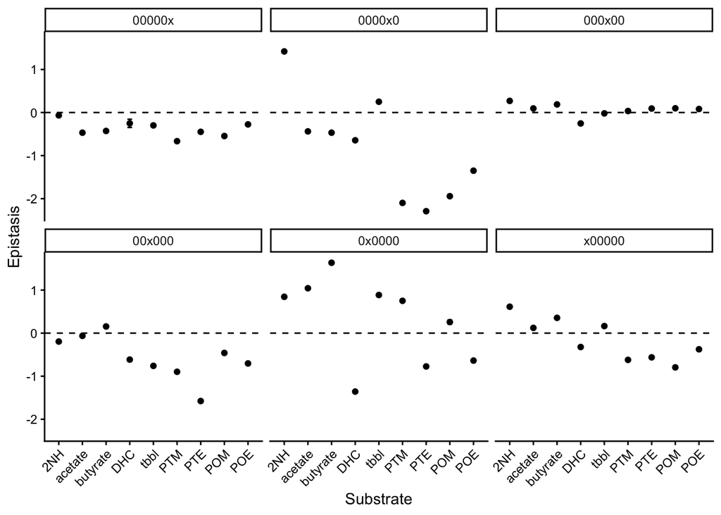

```r
sme_sub_fig <- test_ees %>%
  mutate(sub = factor(sub, levels = c("2NH", "acetate", "butyrate", "DHC", "tbbl", "PTM", "PTE", "POM", "POE"))) %>%
  filter(muts == 1) %>%
  ggplot(aes(x=sub, y = new_val)) +
  geom_point() +
  geom_errorbar(aes(ymin=new_val-new_se, ymax=new_val+new_se), width=.2, position=position_dodge(.9)) +
  geom_hline(yintercept = 0, lty = 2) +
  facet_wrap(~geno) +
  theme_classic() +
  labs(x = "Substrate", y = "Epistasis") +
  theme(axis.text.x = element_text(angle = 45, hjust = 1))

sme_sub_fig
```

```r
##ggsave("sme_sub_fig.svg", plot = sme_sub_fig, width = 180, height = 247/2, dpi = 300, units = "mm")
```

It is worth visualizing how each epistatic coefficient looks for each substrate. Here I can order them by class (esters, lactonse, OPs), then visualize the changes in the magnitude of the epistatic coefficient. Red represents non-sigificant points while blue represents significant.

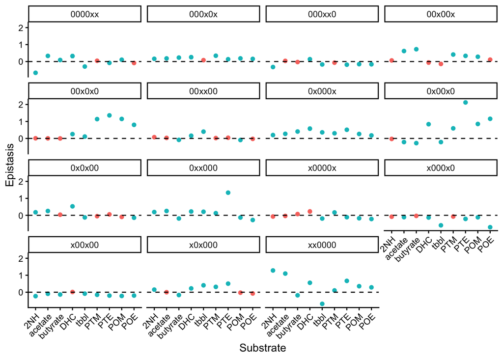

```r
ee2_sub_fig <- test_ees %>%
  mutate(sub = factor(sub, levels = c("2NH", "acetate", "butyrate", "DHC", "tbbl", "PTM", "PTE", "POM", "POE"))) %>%
  filter(muts == 2) %>%
  ggplot(aes(x=sub, y = new_val, color = sig)) +
  geom_point() +
  geom_errorbar(aes(ymin=new_val-new_se, ymax=new_val+new_se), width=.2, position=position_dodge(.9)) +
  geom_hline(yintercept = 0, lty = 2) +
  facet_wrap(~geno) +
  theme_classic() +
  labs(x = "Substrate", y = "Epistasis") +
  theme(axis.text.x = element_text(angle = 45, hjust = 1), legend.position = "none")

ee2_sub_fig
```

```r
##ggsave("ee2_sub_figb_fig.svg", plot = ee2_sub_fig, width = 180, height = 247/2, dpi = 300, units = "mm")
```

Now by 3rd order

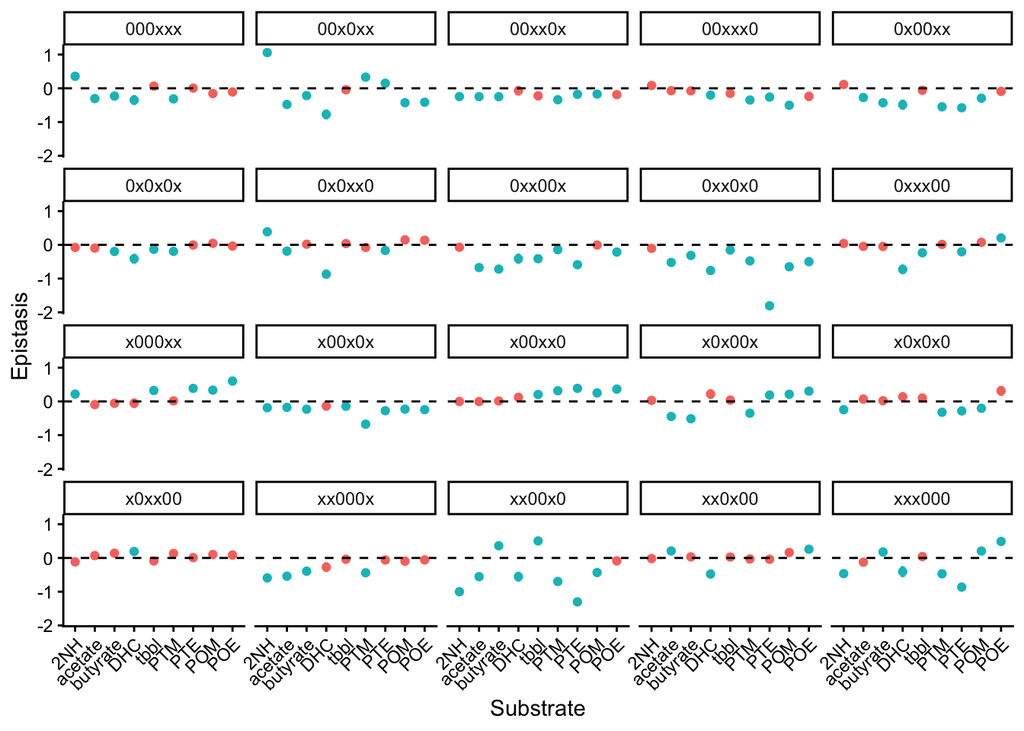

```r
ee3_sub_fig <- test_ees %>%
  mutate(sub = factor(sub, levels = c("2NH", "acetate", "butyrate", "DHC", "tbbl", "PTM", "PTE", "POM", "POE"))) %>%
  filter(muts == 3) %>%
  ggplot(aes(x=sub, y = new_val, color = sig)) +
  geom_point() +
  geom_errorbar(aes(ymin=new_val-new_se, ymax=new_val+new_se), width=.2, position=position_dodge(.9)) +
  geom_hline(yintercept = 0, lty = 2) +
  facet_wrap(~geno) +
  theme_classic() +
  labs(x = "Substrate", y = "Epistasis") +
  theme(axis.text.x = element_text(angle = 45, hjust = 1), legend.position = "none")

ee3_sub_fig
```

```r
##ggsave("ee3_sub_figb_fig.svg", plot = ee3_sub_fig, width = 180, height = 247/2, dpi = 300, units = "mm")
```

Now by 4th order

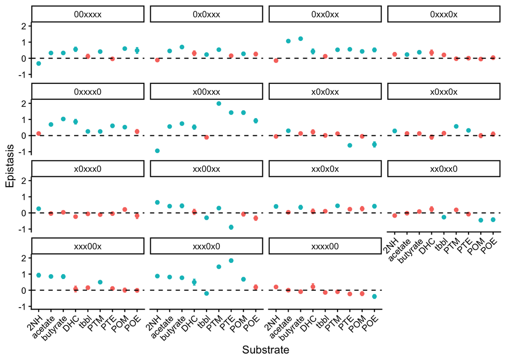

```r
ee4_sub_fig <- test_ees %>%
  mutate(sub = factor(sub, levels = c("2NH", "acetate", "butyrate", "DHC", "tbbl", "PTM", "PTE", "POM", "POE"))) %>%
  filter(muts == 4) %>%
  ggplot(aes(x=sub, y = new_val, color = sig)) +
  geom_point() +
  geom_errorbar(aes(ymin=new_val-new_se, ymax=new_val+new_se), width=.2, position=position_dodge(.9)) +
  geom_hline(yintercept = 0, lty = 2) +
  facet_wrap(~geno) +
  theme_classic() +
  labs(x = "Substrate", y = "Epistasis") +
  theme(axis.text.x = element_text(angle = 45, hjust = 1), legend.position = "none")

ee4_sub_fig
```

```r
##ggsave("ee4_sub_figb_fig.svg", plot = ee4_sub_fig, width = 180, height = 247/2, dpi = 300, units = "mm")
```

Finally 5th order

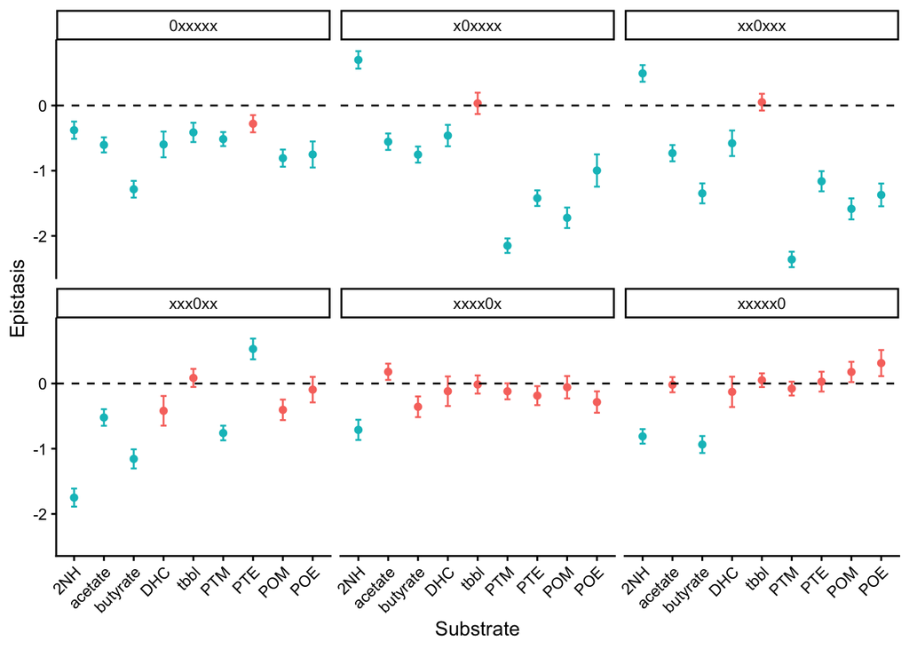

```r
ee5_sub_fig <- test_ees %>%
  mutate(sub = factor(sub, levels = c("2NH", "acetate", "butyrate", "DHC", "tbbl", "PTM", "PTE", "POM", "POE"))) %>%
  filter(muts == 5) %>%
  ggplot(aes(x=sub, y = new_val, color = sig)) +
  geom_point() +
  geom_errorbar(aes(ymin=new_val-new_se, ymax=new_val+new_se), width=.2, position=position_dodge(.9)) +
  geom_hline(yintercept = 0, lty = 2) +
  facet_wrap(~geno) +
  theme_classic() +
  labs(x = "Substrate", y = "Epistasis") +
  theme(axis.text.x = element_text(angle = 45, hjust = 1), legend.position = "none")

ee5_sub_fig
```

```r
##ggsave("ee5_sub_figb_fig.svg", plot = ee5_sub_fig, width = 180, height = 247/2, dpi = 300, units = "mm")
```

We can also plot them by epistatic coefficient to look at the breadth of distribution across substrates. Large spread indicates significantly different wiring for the SME or EE across substrates:

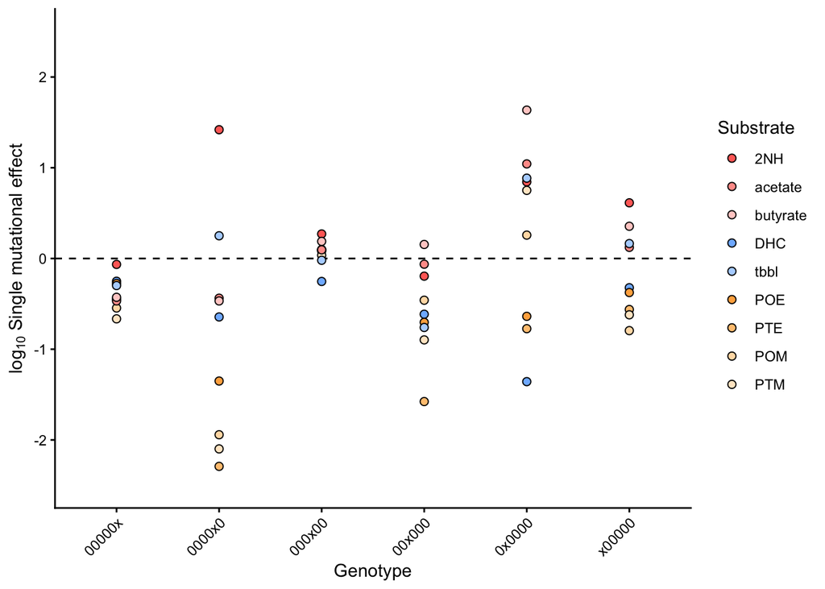

```r
sme_sub_fig_2 <- test_ees %>%
  mutate(sub = factor(sub, levels = c("2NH", "acetate", "butyrate", "DHC", "tbbl", "POE", "PTE", "POM", "PTM")),
         geno = factor(geno)) %>%
  filter(muts == 1) %>%
  ggplot(aes(x = geno, y = new_val, fill = sub)) +
  geom_hline(yintercept = 0, lty = 2) +
  geom_point(pch = 21, size = 2, stroke = 0.5) +
  #geom_errorbar(aes(ymin=new_val-new_se, ymax=new_val+new_se), width=.2, position=position_dodge(.9)) +
  ylim(c(-2.5, 2.5)) +
  scale_fill_manual(values = c("#ff6e66", "#ff9e99", "#ffcfcc", "#80b9ff", "#b3d5ff", "#ffaf4d", "#ffc680", "#ffddb3", "#ffe8cc")) +
  theme_classic() +
  labs(x = "Genotype", y = expression('log'[10]*' Single mutational effect'), fill = "Substrate") +
  theme(axis.text.x = element_text(angle = 45, hjust = 1))

sme_sub_fig_2
```

```r
##ggsave("sme_sub_fig_2.svg", plot = sme_sub_fig_2, width = 180, height = 247/2, dpi = 300, units = "mm")
```

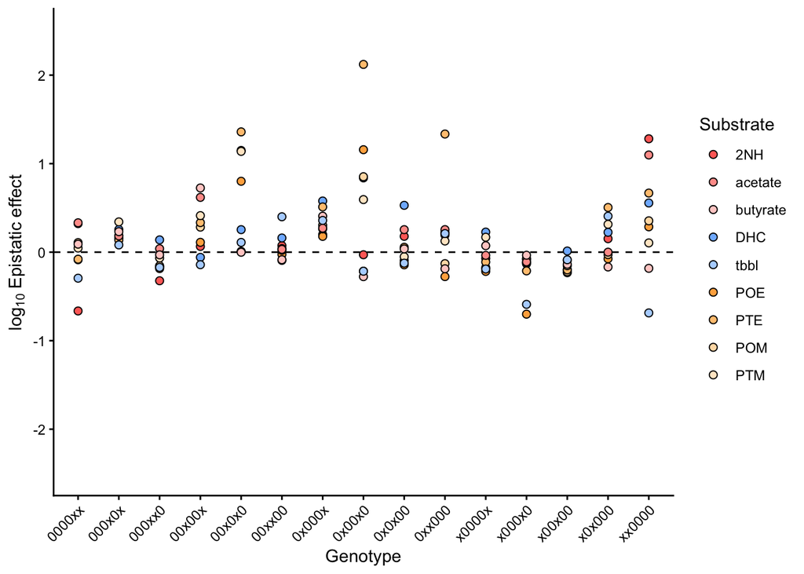

```r
ee2_sub_fig_2 <- test_ees %>%
  mutate(sub = factor(sub, levels = c("2NH", "acetate", "butyrate", "DHC", "tbbl", "POE", "PTE", "POM", "PTM")),
         geno = factor(geno)) %>%
  filter(muts == 2) %>%
  ggplot(aes(x = geno, y = new_val, fill = sub)) +
  geom_hline(yintercept = 0, lty = 2) +
  geom_point(pch = 21, size = 2, stroke = 0.5) +
  #geom_errorbar(aes(ymin=new_val-new_se, ymax=new_val+new_se), width=.2, position=position_dodge(.9)) +
  ylim(c(-2.5, 2.5)) +
  scale_fill_manual(values = c("#ff6e66", "#ff9e99", "#ffcfcc", "#80b9ff", "#b3d5ff", "#ffaf4d", "#ffc680", "#ffddb3", "#ffe8cc")) +
  theme_classic() +
  labs(x = "Genotype", y = expression('log'[10]*' Epistatic effect'), fill = "Substrate") +
  theme(axis.text.x = element_text(angle = 45, hjust = 1))

ee2_sub_fig_2
```

```r
##ggsave("sme_sub_fig_2.svg", plot = sme_sub_fig_2, width = 180, height = 247/2, dpi = 300, units = "mm")
```

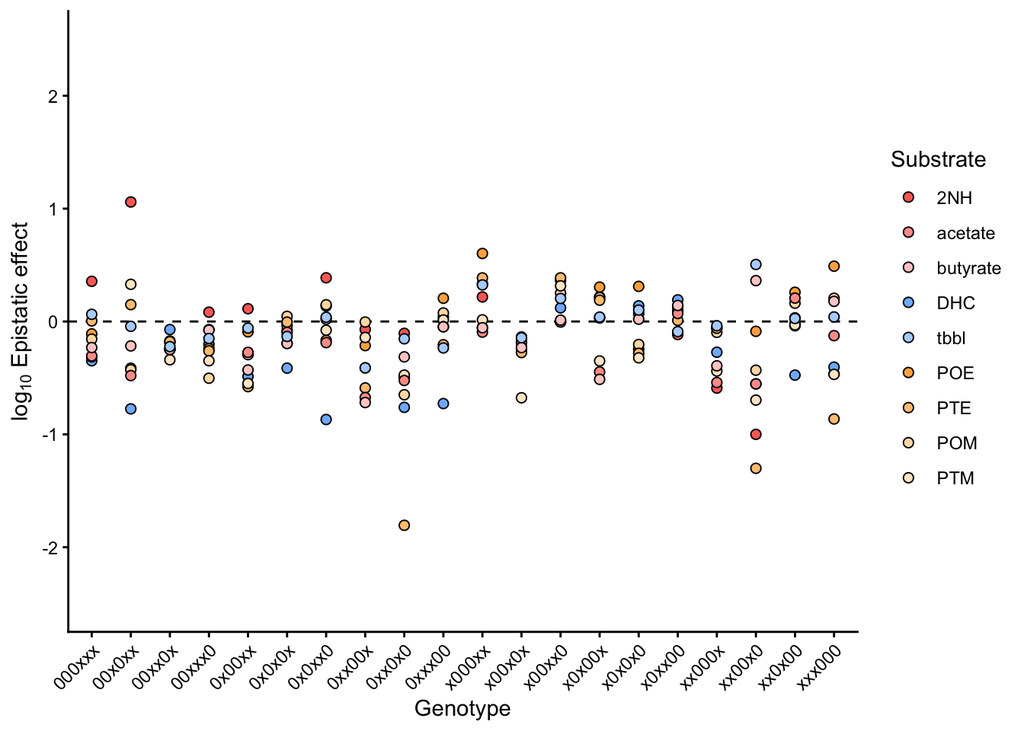

```r
ee3_sub_fig_2 <- test_ees %>%
  mutate(sub = factor(sub, levels = c("2NH", "acetate", "butyrate", "DHC", "tbbl", "POE", "PTE", "POM", "PTM")),
         geno = factor(geno)) %>%
  filter(muts == 3) %>%
  ggplot(aes(x = geno, y = new_val, fill = sub)) +
  geom_hline(yintercept = 0, lty = 2) +
  geom_point(pch = 21, size = 2, stroke = 0.5) +
  #geom_errorbar(aes(ymin=new_val-new_se, ymax=new_val+new_se), width=.2, position=position_dodge(.9)) +
  ylim(c(-2.5, 2.5)) +
  scale_fill_manual(values = c("#ff6e66", "#ff9e99", "#ffcfcc", "#80b9ff", "#b3d5ff", "#ffaf4d", "#ffc680", "#ffddb3", "#ffe8cc")) +
  theme_classic() +
  labs(x = "Genotype", y = expression('log'[10]*' Epistatic effect'), fill = "Substrate") +
  theme(axis.text.x = element_text(angle = 45, hjust = 1))

ee3_sub_fig_2
```

```r
##ggsave("sme_sub_fig_2.svg", plot = sme_sub_fig_2, width = 180, height = 247/2, dpi = 300, units = "mm")
```

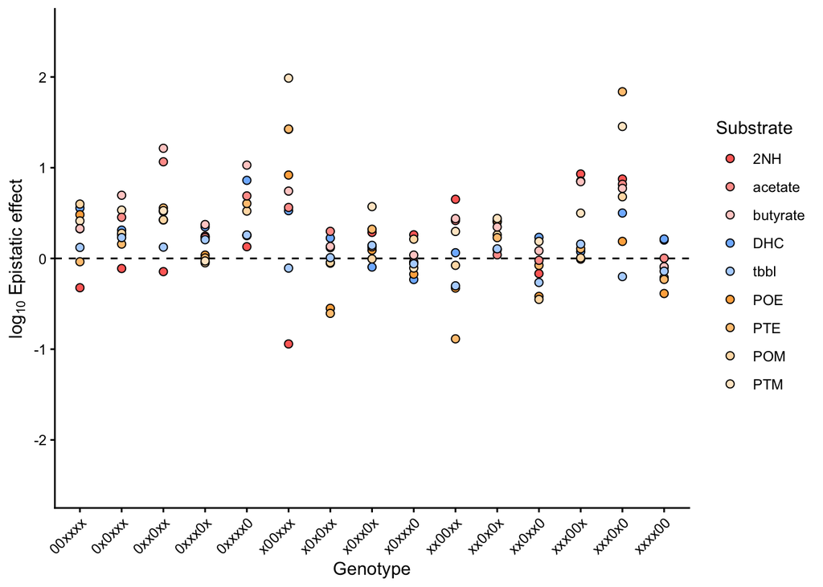

```r
ee4_sub_fig_2 <- test_ees %>%
  mutate(sub = factor(sub, levels = c("2NH", "acetate", "butyrate", "DHC", "tbbl", "POE", "PTE", "POM", "PTM")),
         geno = factor(geno)) %>%
  filter(muts == 4) %>%
  ggplot(aes(x = geno, y = new_val, fill = sub)) +
  geom_hline(yintercept = 0, lty = 2) +
  geom_point(pch = 21, size = 2, stroke = 0.5) +
  #geom_errorbar(aes(ymin=new_val-new_se, ymax=new_val+new_se), width=.2, position=position_dodge(.9)) +
  ylim(c(-2.5, 2.5)) +
  scale_fill_manual(values = c("#ff6e66", "#ff9e99", "#ffcfcc", "#80b9ff", "#b3d5ff", "#ffaf4d", "#ffc680", "#ffddb3", "#ffe8cc")) +
  theme_classic() +
  labs(x = "Genotype", y = expression('log'[10]*' Epistatic effect'), fill = "Substrate") +
  theme(axis.text.x = element_text(angle = 45, hjust = 1))

ee4_sub_fig_2
```

```r
##ggsave("sme_sub_fig_2.svg", plot = sme_sub_fig_2, width = 180, height = 247/2, dpi = 300, units = "mm")
```

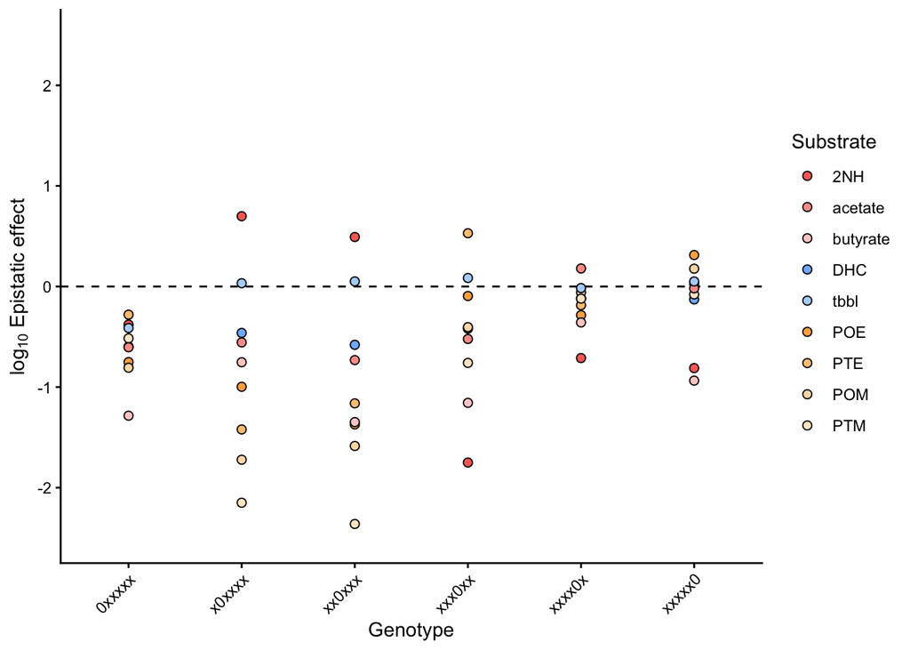

```r
ee5_sub_fig_2 <- test_ees %>%
  mutate(sub = factor(sub, levels = c("2NH", "acetate", "butyrate", "DHC", "tbbl", "POE", "PTE", "POM", "PTM")),
         geno = factor(geno)) %>%
  filter(muts == 5) %>%
  ggplot(aes(x = geno, y = new_val, fill = sub)) +
  geom_hline(yintercept = 0, lty = 2) +
  geom_point(pch = 21, size = 2, stroke = 0.5) +
  #geom_errorbar(aes(ymin=new_val-new_se, ymax=new_val+new_se), width=.2, position=position_dodge(.9)) +
  ylim(c(-2.5, 2.5)) +
  scale_fill_manual(values = c("#ff6e66", "#ff9e99", "#ffcfcc", "#80b9ff", "#b3d5ff", "#ffaf4d", "#ffc680", "#ffddb3", "#ffe8cc")) +
  theme_classic() +
  labs(x = "Genotype", y = expression('log'[10]*' Epistatic effect'), fill = "Substrate") +
  theme(axis.text.x = element_text(angle = 45, hjust = 1))

ee5_sub_fig_2
```

```r
##ggsave("sme_sub_fig_2.svg", plot = sme_sub_fig_2, width = 180, height = 247/2, dpi = 300, units = "mm")
```

### 3.4.2 Exporting files for visualization in PyMol

The csvs are then individually processed to plot 1st, 2nd, 3rd, 4th, and 5th order information in a .pse session in PyMol.

```r
test_ees_pos <- test_ees %>%
  select(new_val, sig, sub, geno) %>%
  separate(geno, into = letters[1:7], sep = "", remove = F) %>% # not sure why "a" has nothing
  select(-c(a)) %>% # so I just drop it
  mutate(b = if_else(b == 0, NA, "233"),
     c = if_else(c == 0, NA, "254"),
     d = if_else(d == 0, NA, "271"),
     e = if_else(e == 0, NA, "272"),
     f = if_else(f == 0, NA, "306"),
     g = if_else(g == 0, NA, "313")) %>%
  unite("positions", b:g, sep = "|", na.rm = T)

# Loop by substrate, keep it in the csv name but remove it from the datafarme

for(i in 1:length(unique(test_ees_pos$sub))) {
  cur_sub = unique(test_ees_pos$sub)[i]

  test_ees_pos %>%
    filter(sub == cur_sub) %>%
    select(-c(sub)) %>%
    write_csv(., file = paste(cur_sub, "_ee_list.csv", sep = ""))
}
```

## 3.5 Normalizing bespoke pairs by single substrate

Another approach to “treating different substrates as mutations” can be achieved by normalizing initial rate data to a common substrate. Although this makes the analysis tricky when dealing with all substrates sets, due to the strong magnitude skew from paraoxon rate, some chosen substrates can be treated this way.

### 3.5.1 Paraoxon-ethyl (POE) vs Paraoxon-methyl (POM)

```r
poe_pom_data <- processed_data %>%
  filter(substrate %in% c("POE", "POM")) %>%
  mutate(substrate = case_when(substrate == "POE" ~ 0, substrate == "POM" ~ 1)) %>%
  select(-c(replicate, exp_day, plate_id))

poe_pom_wt_mean <- mean(poe_pom_data %>% filter(if_all(1:7, ~. == 0)) %>% pull(activity))

poe_pom_norm_data <- poe_pom_data %>%
  mutate(activity = activity/poe_pom_wt_mean,
         log.activity = log10(activity))
```

After constructing the data, we can visualize the distribution based on different substrate:

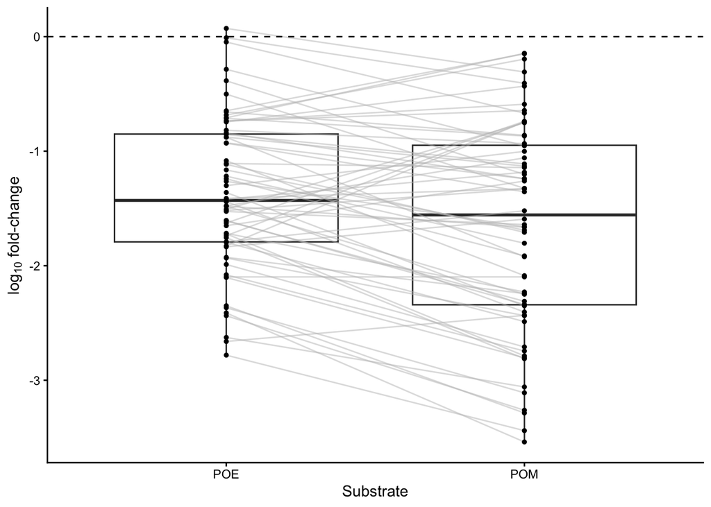

```r
poe_pom_box_fig <- poe_pom_norm_data %>%
  group_by(p233, p254, p271, p272, p306, p313, substrate, reference) %>%
  summarize(log.activity = mean(log.activity)) %>%
  ungroup() %>%
  mutate(substrate = case_when(substrate == 0 ~ "POE", substrate == 1 ~ "POM")) %>%
  ggplot(aes(x = substrate, y = log.activity)) +
  geom_boxplot() +
  geom_line(aes(group=reference), color = "grey", alpha = 0.5) + # clever way to connect points between group
  geom_point(size = 1) +
  geom_hline(yintercept = 0, lty = 2) +
  labs(x = "Substrate", y = expression("log"[10]*" fold-change")) +
  theme_classic()

poe_pom_box_fig
```

```r
##ggsave("poe_pom_box_fig.svg", plot = poe_pom_box_fig, width = 180/2, height = 247/3, dpi = 300, units = "mm")
```

This plot essentially outlines the single mutational effects of “mutating” paraoxon-ethyl into paraoxon-methyl, and the scale is accurate as it has all been normalized to wt with paraoxon. *It will be worth taking those “slopes” (which are ratios) and figuring out which genotypes are more or less tolerant to methyl substitution.*

This can be further explored by looking into “epistasis” between a “mutation” from POE to POM and mutation(s) at other amino acids. I can use the same pipeline for error propagation as I have before (need to clean up some of my mean calculation post 2 substrate normalization) to then analyze significant epistasis between a substrate and position. *ACTUALLY, I don’t think I have to do this. Since I have epistasis data for each substrate normalized to itself, the epistasis information should still hold?*